# LASER-seq data analysis pipeline and downstream analysis

### set up imports, set up preferences, and run mapping and counting pipeline

```python
#add pipeline to path
import sys
import datetime
import os
import os.path as path
#the pipeline code and the data can be in seperate directories
#if this is the case, put the absolute path to the directory in the quotes below
pipeline_dir = '/fastscratch/boris/LASER_seq_2018'
if pipeline_dir not in sys.path:
    sys.path.append(pipeline_dir)

import mod_seq_main
import mod_settings
import mod_utils
import mod_lib
import mod_plotting

def current_time():
    return datetime.datetime.now().strftime("%Y%m%d_%H%M")
def current_date():
    return datetime.datetime.now().strftime("%Y%m%d")
```

Here is a sample input settings file used for this paper, with notes. The settings file is in JSON format, and no comments are allowed, so I provide here an explanation. The actual files used for the paper are includedin the github.

Note that all quotes are double quotes, and spaces and special characters must be avoided in sample and file names.

[ input ]

fastq_dir = /fastscratch/boris/2.99/FASTQ #path to FASTQ files, which should be gzipped

# names of files

fastq_gz_files = ["HJHLTBCXY_2_AGGTTT_1.fastq.gz", "HJHLTBCXY_2_CCTGAG_1.fastq.gz", "HJHLTBCXY_2_GAACCC_1.fastq.gz", "HJHLTBCXY_2_TTCAGA_1.fastq.gz", "HJHLTBCXY_2_TGCTGT_1.fastq.gz", "HJHLTBCXY_2_CATCAC_1.fastq.gz","HJHLTBCXY_2_GTAACA_1.fastq.gz","HJHLTBCXY_2_GGATCT_1.fastq.gz","HJHLTBCXY_2_TCCGGG_1.fastq.gz","HJHLTBCXY_2_AAGCTC_1.fastq.gz","HJHLTBCXY_2_CAAGTT_1.fastq.gz","HJHLTBCXY_2_GTCCAG_1.fastq.gz","HJHLTBCXY_2_TGGACC_1.fastq.gz","HJHLTBCXY_2_ACTTGA_1.fastq.gz","HJHLTBCXY_2_AATGGT_1.fastq.gz","HJHLTBCXY_2_GGCAAC_1.fastq.gz","HJHLTBCXY_2_TCGTCA_1.fastq.gz","HJHLTBCXY_2_TAGGCT_1.fastq.gz","HJHLTBCXY_2_ATTCGG_1.fastq.gz","HJHLTBCXY_2_CGAATC_1.fastq.gz"]

# order of sample names MUST match the order of file names

sample_names = ["1_70S_None_SSII_FL","2_70S_UV_SSII_FL","3_70S_UV_NAZ_SSII_FL","4_70S_EFG_UV_NAZ_SSII_FL","5_70S_EFG_GDPNP_UV_NAZ_SSII_FL","7_70S_None_tgirt_FL","8_70S_UV_tgirt_FL","9_70S_UV_NAZ_tgirt_FL","10_70S_EFG_UV_NAZ_tgirt_FL","11_70S_EFG_GDPNP_UV_NAZ_tgirt_FL","13_70S_None_SSII_Trunc","14_70S_UV_SSII_Trunc","15_70S_UV_NAZ_SSII_Trunc","16_70S_EFG_UV_NAZ_SSII_Trunc","17_70S_EFG_GDPNP_UV_NAZ_SSII_Trunc","19_70S_None_tgirt_Trunc","20_70S_UV_tgirt_Trunc","21_70S_UV_NAZ_tgirt_Trunc","22_70S_EFG_UV_NAZ_tgirt_Trunc","23_70S_EFG_GDPNP_UV_NAZ_tgirt_Trunc"]

# numerators for comparisons

experimentals = ["4_70S_EFG_UV_NAZ_SSII_FL","5_70S_EFG_GDPNP_UV_NAZ_SSII_FL","10_70S_EFG_UV_NAZ_tgirt_FL","11_70S_EFG_GDPNP_UV_NAZ_tgirt_FL","16_70S_EFG_UV_NAZ_SSII_Trunc","17_70S_EFG_GDPNP_UV_NAZ_SSII_Trunc", "22_70S_EFG_UV_NAZ_tgirt_Trunc","23_70S_EFG_GDPNP_UV_NAZ_tgirt_Trunc"] unmodified control for each dataset. no_mod_controls= ["2_70S_UV_SSII_FL", "2_70S_UV_SSII_FL", "8_70S_UV_tgirt_FL", "8_70S_UV_tgirt_FL", "14_70S_UV_SSII_Trunc", "14_70S_UV_SSII_Trunc", "20_70S_UV_tgirt_Trunc", "20_70S_UV_tgirt_Trunc"]

# denominators for comparisons

with_mod_controls = ["3_70S_UV_NAZ_SSII_FL", "3_70S_UV_NAZ_SSII_FL","9_70S_UV_NAZ_tgirt_FL", "9_70S_UV_NAZ_tgirt_FL", "15_70S_UV_NAZ_SSII_Trunc", "15_70S_UV_NAZ_SSII_Trunc", "21_70S_UV_NAZ_tgirt_Trunc", "21_70S_UV_NAZ_tgirt_Trunc"]

[ parameters ]

experiment_name = batch1_EFG

rrna_fasta = MRE600_rRNA_consensus.fa #path to a fasta file with the transcripts to align to

tptn_file_18s = ""

tptn_file_25s = ""

exclude_constitutive = {"E.c.16S_rRNA":[1207, 1498, 1518, 1519],"E.c.23S_rRNA":[745, 1915]} #nucleotides that are modified in vivo and should be avoided

confidence_interval_cutoff = 0.999

fold_change_cutoff = 1.2

winsorization_upper_limit = 1.00

pymol_base_script = ""

pymol_base_script_colorchange = ''

functional_groupings = ''

make_interactive_plots = True #interactive MA plots are good for identifying protected nucleotides

adaptor_sequence = CACTCGGGCACCAAGGAC

affected_nucleotides = AG

discard_untrimmed = False #if the read length is long enough that you expect to detect the 3' adaptor in most reads, it might be worth discarding reads that fail to be trimmed.

min_post_adaptor_length = 16

first_base_to_keep = 1 #This should not be a problem since shapemapper 2.0 ignores soft-clipped nucleotides, but this can be increased to strip nucleotides from the 5' end, where untemplated nucleotide addition can be an issue for MaP analysis. However, this will break the RT stop analysis.

last_base_to_keep = 100 #i keep this longer than the read lengt, there is rarely need to trim the 3' end

min_base_quality = 20

min_mapping_quality = 10

[ output ]

results_dir = /fastscratch/boris/LASER_seq_results/batch1_efg #the folder to put the output of the analysis pipeline

```python
# Now run the mod_seq pipeline to get the dataset objects
#that contain the counted mutation rates and RT stops
threads = 70 #Adjust this depending on how many cores you have available

ecoli_batch1_settings_file = 'settings_Ecoli_efg.json.txt'
ecoli_batch1_settings = mod_settings.mod_settings(ecoli_batch1_settings_file)
ecoli_batch1_datasets = mod_seq_main.mod_seq_run(ecoli_batch1_settings, threads)
```

```python
[library.lib_settings.sample_name for library in ecoli_batch1_datasets.libs]
```

```
['1_70S_None_SSII_FL',
 '2_70S_UV_SSII_FL',
 '3_70S_UV_NAZ_SSII_FL',
 '4_70S_EFG_UV_NAZ_SSII_FL',
 '5_70S_EFG_GDPNP_UV_NAZ_SSII_FL',
 '7_70S_None_tgirt_FL',
 '8_70S_UV_tgirt_FL',
 '9_70S_UV_NAZ_tgirt_FL',
 '10_70S_EFG_UV_NAZ_tgirt_FL',
 '11_70S_EFG_GDPNP_UV_NAZ_tgirt_FL',
 '13_70S_None_SSII_Trunc',
 '14_70S_UV_SSII_Trunc',
 '15_70S_UV_NAZ_SSII_Trunc',
 '16_70S_EFG_UV_NAZ_SSII_Trunc',
 '17_70S_EFG_GDPNP_UV_NAZ_SSII_Trunc',
 '19_70S_None_tgirt_Trunc',
 '20_70S_UV_tgirt_Trunc',
 '21_70S_UV_NAZ_tgirt_Trunc',
 '22_70S_EFG_UV_NAZ_tgirt_Trunc',
 '23_70S_EFG_GDPNP_UV_NAZ_tgirt_Trunc']
```

```python
#set up plotting
%matplotlib inline
import matplotlib as mpl
import matplotlib.pyplot as plt
plt.rcParams['pdf.fonttype'] = 42 #leaves most text as actual text in PDFs, not outlines
```

## Figures 2A & B: Step plots of mutation and RT stops in G530 region of 16S E. coli rRNA

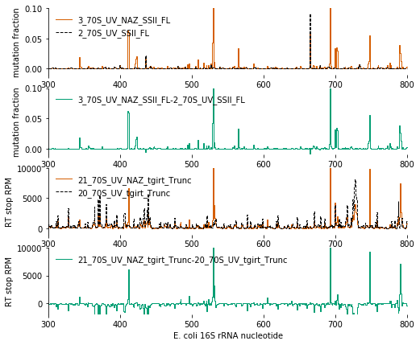

```python
import scipy.stats as stats
import math
import numpy

def plot_mutation_step(axis, lib_name, rRNA_name, start_position, end_position, color, subtract_background=False, alpha=1,
                      ymin=-.01, ymax =0.1, linestyle='-'):
    library = ecoli_batch1_datasets.get_lib_from_name(lib_name)
    x = range(start_position, end_position+1)
    y = []
    for rRNA_position in x:
        nuc = library.get_nucleotide(rRNA_name, rRNA_position)
        if subtract_background:
            mutation_fraction = nuc.get_back_sub_mutation_rate()
        else:
            mutation_fraction = nuc.mutation_rate
        y.append(mutation_fraction)
    if subtract_background:
        axis.step(x, y, color=color, label='%s-%s' % (library.lib_settings.sample_name, library.get_normalizing_lib().lib_settings.sample_name),
                  lw=1, alpha=alpha, linestyle=linestyle)
    else:
        axis.step(x, y, color=color, label='%s' % (library.lib_settings.sample_name), lw=1, alpha=alpha, linestyle=linestyle)
    plot.set_ylim(ymin,ymax)
    plot.set_xlim(start_position, end_position+1)
    plot.spines['right'].set_visible(False)
    plot.spines['top'].set_visible(False)
    plot.spines['bottom'].set_visible(False)
    plot.set_ylabel('mutation fraction')

def plot_rt_stop_step(axis, lib_name, rRNA_name, start_position, end_position, color, subtract_background=False, alpha=1,
                     ymin=-1000, ymax=10000, linestyle='-'):
    library = ecoli_batch1_datasets.get_lib_from_name(lib_name)
    x = range(start_position, end_position+1)
    y = []
    for rRNA_position in x:
        nuc = library.get_nucleotide(rRNA_name, rRNA_position)
        if subtract_background:
            rt_stop_rpm = nuc.get_rt_stop_rpm()-nuc.get_background_nucleotide().get_rt_stop_rpm()
        else:
            rt_stop_rpm = nuc.get_rt_stop_rpm()
        y.append(rt_stop_rpm)
    if subtract_background:
        axis.step(x, y, color=color, label='%s-%s' % (library.lib_settings.sample_name, library.get_normalizing_lib().lib_settings.sample_name),
                  lw=1, alpha=alpha, linestyle=linestyle)
    else:
        axis.step(x, y, color=color, label='%s' % (library.lib_settings.sample_name), lw=1, alpha=alpha, linestyle=linestyle)
    plot.set_ylim(ymin,ymax)
    plot.set_xlim(start_position, end_position+1)
    plot.spines['right'].set_visible(False)
    plot.spines['top'].set_visible(False)
    plot.spines['bottom'].set_visible(False)
    plot.set_ylabel('RT stop RPM')


rRNA = 'E.c.16S_rRNA'
start = 300
end = 800
fig = plt.figure(figsize=(8,7))
plot = fig.add_subplot(411)
plot_mutation_step(plot, '3_70S_UV_NAZ_SSII_FL', rRNA, start, end, mod_utils.vermillion, subtract_background=False, alpha=1)
plot_mutation_step(plot, '2_70S_UV_SSII_FL', rRNA , start, end, mod_utils.black, subtract_background=False, linestyle='dashed')

lg=plot.legend(loc=2)
lg.draw_frame(False)
plot = fig.add_subplot(412)
plot_mutation_step(plot, '3_70S_UV_NAZ_SSII_FL', rRNA, start, end, mod_utils.bluishGreen, subtract_background=True, alpha=1,
                   ymin =-0.01)
lg=plot.legend(loc=2)
lg.draw_frame(False)

plot = fig.add_subplot(413)
plot_rt_stop_step(plot, '21_70S_UV_NAZ_tgirt_Trunc', rRNA, start, end, mod_utils.vermillion, subtract_background=False, alpha=1)
plot_rt_stop_step(plot, '20_70S_UV_tgirt_Trunc', rRNA, start, end, mod_utils.black, subtract_background=False, linestyle='dashed')
lg=plot.legend(loc=2)
lg.draw_frame(False)
plot = fig.add_subplot(414)
plot_rt_stop_step(plot, '21_70S_UV_NAZ_tgirt_Trunc', rRNA, start, end, mod_utils.bluishGreen, subtract_background=True, alpha=1,
                 ymin = -2000)
lg=plot.legend(loc=2)
lg.draw_frame(False)
plot.set_xlabel('E. coli 16S rRNA nucleotide')
plt.savefig('figures_2AB_%s_%s.pdf' % (current_date(), current_time()), transparent='True', format='pdf')
```

## Figure 2C: CDF of mutation rates for all 4 nucleotides in E. coli ribosomes

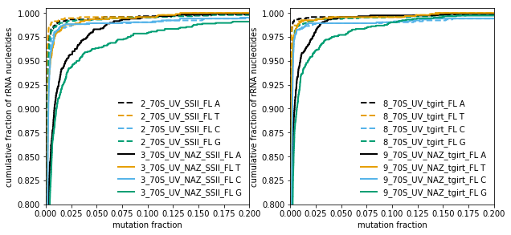

```python
#plot mutation CDF plots for E coli data
import scipy.stats as stats
import math
import numpy

lib_names = ['2_70S_UV_SSII_FL', '3_70S_UV_NAZ_SSII_FL', '20_70S_UV_tgirt_Trunc', '21_70S_UV_NAZ_tgirt_Trunc']

colors = {'A':mod_utils.black, 'T':mod_utils.orange, 'C':mod_utils.skyBlue , 'G':mod_utils.bluishGreen }

fig = plt.figure(figsize=(10,4.5))

ax1 = fig.add_subplot(121)
for lib_name in ['2_70S_UV_SSII_FL']:
    library = ecoli_batch1_datasets.get_lib_from_name(lib_name)
    for nuc in 'ATCG':
        mutations = [val for val in library.list_mutation_rates(subtract_background=False, subtract_control=False,
                                                        nucleotides_to_count=nuc,
                                                        exclude_constitutive=True)]
        n = numpy.arange(1,len(mutations)+1) / numpy.float(len(mutations))
        Xs = numpy.sort(mutations)
        ax1.step(Xs,n, color=colors[nuc],
                  label='%s %s' % (library.lib_settings.sample_name, nuc), lw=2, linestyle='dashed')
for lib_name in ['3_70S_UV_NAZ_SSII_FL']:
    library = ecoli_batch1_datasets.get_lib_from_name(lib_name)
    for nuc in 'ATCG':
        mutations = [val for val in library.list_mutation_rates(subtract_background=False, subtract_control=False,
                                                        nucleotides_to_count=nuc,
                                                        exclude_constitutive=True)]
        n = numpy.arange(1,len(mutations)+1) / numpy.float(len(mutations))
        Xs = numpy.sort(mutations)
        ax1.step(Xs,n, color=colors[nuc],
                  label='%s %s' % (library.lib_settings.sample_name, nuc), lw=2)

ax1.set_ylabel('cumulative fraction of rRNA nucleotides')
ax1.set_xlabel('mutation fraction')
ax1.set_ylim(.80, 1.005)
ax1.set_xlim(0, 0.2)
lg=ax1.legend(loc=4)
lg.draw_frame(False)

ax1 = fig.add_subplot(122)
for lib_name in ['8_70S_UV_tgirt_FL']:
    library = ecoli_batch1_datasets.get_lib_from_name(lib_name)
    for nuc in 'ATCG':
        mutations = [val for val in library.list_mutation_rates(subtract_background=False, subtract_control=False,
                                                        nucleotides_to_count=nuc,
                                                        exclude_constitutive=True)]
        n = numpy.arange(1,len(mutations)+1) / numpy.float(len(mutations))
        Xs = numpy.sort(mutations)
        ax1.step(Xs,n, color=colors[nuc],
                  label='%s %s' % (library.lib_settings.sample_name, nuc), lw=2, linestyle='dashed')
for lib_name in ['9_70S_UV_NAZ_tgirt_FL']:
    library = ecoli_batch1_datasets.get_lib_from_name(lib_name)
    for nuc in 'ATCG':
        mutations = [val for val in library.list_mutation_rates(subtract_background=False, subtract_control=False,
                                                        nucleotides_to_count=nuc,
                                                        exclude_constitutive=True)]
        n = numpy.arange(1,len(mutations)+1) / numpy.float(len(mutations))
        Xs = numpy.sort(mutations)
        ax1.step(Xs,n, color=colors[nuc],
                  label='%s %s' % (library.lib_settings.sample_name, nuc), lw=2)

ax1.set_ylabel('cumulative fraction of rRNA nucleotides')
ax1.set_xlabel('mutation fraction')
#ax1.set_xscale('log')
ax1.set_ylim(.80, 1.005)
ax1.set_xlim(0, 0.2)
lg=ax1.legend(loc=4)
lg.draw_frame(False)

plt.savefig('Figure_2C_e_coli_misincorp_cdf_%s_%s.pdf' % (current_date(), current_time()), transparent='True', format='pdf')
```

## Figure 2D: CDF of RT stop RPMs

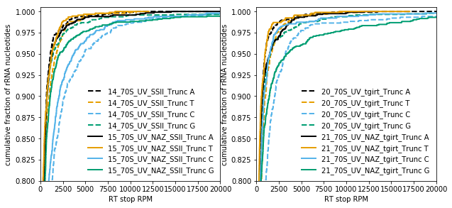

```python
import scipy.stats as stats
import math
import numpy

#Makes cdf plots of raw mutation rates
colors = {'A':mod_utils.black, 'T':mod_utils.orange, 'C':mod_utils.skyBlue , 'G':mod_utils.bluishGreen }

fig = plt.figure(figsize=(10,4.5))

ax1 = fig.add_subplot(121)
for lib_name in ['14_70S_UV_SSII_Trunc']:
    library = ecoli_batch1_datasets.get_lib_from_name(lib_name)
    for nuc in 'ATCG':
        mutations = [val for val in library.list_rt_stop_rpms(subtract_background=False, subtract_control=False,
                                                        nucleotides_to_count=nuc,
                                                        exclude_constitutive=True)]
        n = numpy.arange(1,len(mutations)+1) / numpy.float(len(mutations))
        Xs = numpy.sort(mutations)
        ax1.step(Xs,n, color=colors[nuc],
                  label='%s %s' % (library.lib_settings.sample_name, nuc), lw=2, linestyle='dashed')
for lib_name in ['15_70S_UV_NAZ_SSII_Trunc']:
    library = ecoli_batch1_datasets.get_lib_from_name(lib_name)
    for nuc in 'ATCG':
        mutations = [val for val in library.list_rt_stop_rpms(subtract_background=False, subtract_control=False,
                                                        nucleotides_to_count=nuc,
                                                        exclude_constitutive=True)]
        n = numpy.arange(1,len(mutations)+1) / numpy.float(len(mutations))
        Xs = numpy.sort(mutations)
        ax1.step(Xs,n, color=colors[nuc],
                  label='%s %s' % (library.lib_settings.sample_name, nuc), lw=2)

ax1.set_ylabel('cumulative fraction of rRNA nucleotides')
ax1.set_xlabel('RT stop RPM')
ax1.set_ylim(.8, 1.005)
ax1.set_xlim(0, 20000)
lg=ax1.legend(loc=4)
lg.draw_frame(False)

ax1 = fig.add_subplot(122)
for lib_name in ['20_70S_UV_tgirt_Trunc']:
    library = ecoli_batch1_datasets.get_lib_from_name(lib_name)
    for nuc in 'ATCG':
        mutations = [val for val in library.list_rt_stop_rpms(subtract_background=False, subtract_control=False,
                                                        nucleotides_to_count=nuc,
                                                        exclude_constitutive=True)]
        n = numpy.arange(1,len(mutations)+1) / numpy.float(len(mutations))
        Xs = numpy.sort(mutations)
        ax1.step(Xs,n, color=colors[nuc],
                  label='%s %s' % (library.lib_settings.sample_name, nuc), lw=2, linestyle='dashed')
for lib_name in ['21_70S_UV_NAZ_tgirt_Trunc']:
    library = ecoli_batch1_datasets.get_lib_from_name(lib_name)
    for nuc in 'ATCG':
        mutations = [val for val in library.list_rt_stop_rpms(subtract_background=False, subtract_control=False,
                                                        nucleotides_to_count=nuc,
                                                        exclude_constitutive=True)]
        n = numpy.arange(1,len(mutations)+1) / numpy.float(len(mutations))
        Xs = numpy.sort(mutations)
        ax1.step(Xs,n, color=colors[nuc],
                  label='%s %s' % (library.lib_settings.sample_name, nuc), lw=2)

ax1.set_ylabel('cumulative fraction of rRNA nucleotides')
ax1.set_xlabel('RT stop RPM')
#ax1.set_xscale('log')
ax1.set_ylim(.8, 1.005)
ax1.set_xlim(0, 20000)
lg=ax1.legend(loc=4)
lg.draw_frame(False)


plt.savefig('Figure2D_e_coli_rt_stop_cdf_%s_%s.pdf' % (current_date(), current_time()), transparent='True', format='pdf')
```

## Figure 2E: CDF of mutation rates between probing reagents for yeast ribosomes

```python
# Now run the mod_seq pipeline to get the dataset objects
#that contain the counted mutation rates and RT stops
threads = 70 #Adjust this depending on how many cores you have available

scerevisiae_settings_file = 'settings_Scerevisiae.json.txt'
scerevisiae_settings = mod_settings.mod_settings(scerevisiae_settings_file)
scerevisiae_datasets = mod_seq_main.mod_seq_run(scerevisiae_settings, threads)
```

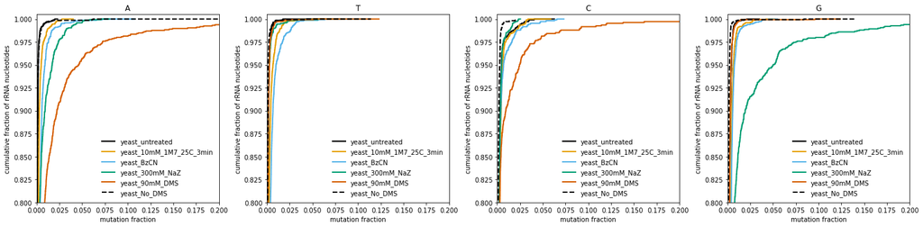

```python
#plot mutation CDF plots for yeast data
import scipy.stats as stats
import math
import numpy

lib_names = ['yeast_untreated',
 'yeast_10mM_1M7_25C_3min',
 'yeast_BzCN',
 'yeast_300mM_NaZ',
 'yeast_90mM_DMS']

#Makes cdf plots of raw mutation rates
colors = {'A':mod_utils.black, 'T':mod_utils.orange, 'C':mod_utils.skyBlue , 'G':mod_utils.bluishGreen }

fig = plt.figure(figsize=(20,5))
plot_index = 0
for nuc in 'ATCG':
    plot_index += 1
    ax1 = fig.add_subplot(1, 4, plot_index)
    lib_index = 0
    for lib_name in lib_names:
        library = scerevisiae_datasets.get_lib_from_name(lib_name)
        mutations = [val for val in library.list_mutation_rates(subtract_background=False, subtract_control=False,
                                                        nucleotides_to_count=nuc,
                                                        exclude_constitutive=True)]

        n = numpy.arange(1,len(mutations)+1) / numpy.float(len(mutations))
        Xs = numpy.sort(mutations)
        ax1.step(Xs,n,  color=mod_utils.colors[lib_index], label='%s' % (library.lib_settings.sample_name), lw=2)

        lib_index+=1
    for lib_name in ['yeast_No_DMS']:
        library = scerevisiae_datasets.get_lib_from_name(lib_name)
        mutations = [val for val in library.list_mutation_rates(subtract_background=False, subtract_control=False,
                                                        nucleotides_to_count=nuc,
                                                        exclude_constitutive=True)]

        n = numpy.arange(1,len(mutations)+1) / numpy.float(len(mutations))
        Xs = numpy.sort(mutations)
        ax1.step(Xs,n,  color=mod_utils.colors[0], label='%s' % (library.lib_settings.sample_name), lw=2, linestyle='dashed')

        lib_index+=1
    ax1.set_title(nuc)
    ax1.set_ylabel('cumulative fraction of rRNA nucleotides')
    ax1.set_xlabel('mutation fraction')
    ax1.set_ylim(.8, 1.005)
    ax1.set_xlim(0, 0.2)
    lg=ax1.legend(loc=4)
    lg.draw_frame(False)

    plt.tight_layout()
plt.savefig('Figure2E_yeast_misincorp_cdf_%s_%s.pdf' % (current_date(), current_time()), transparent='True', format='pdf')
```

## Figures S2: step plots of entire 16S for RT stop RPMs

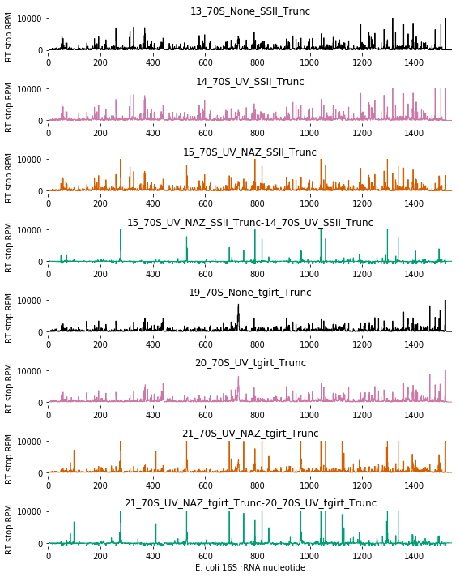

```python
import scipy.stats as stats
import math
import numpy

def plot_rt_stop_step(axis, lib_name, rRNA_name, start_position, end_position, color, subtract_background=False, alpha=1,
                     ymin=-1000, ymax=10000):
    library = ecoli_batch1_datasets.get_lib_from_name(lib_name)
    x = range(start_position, end_position+1)
    y = []
    for rRNA_position in x:
        nuc = library.get_nucleotide(rRNA_name, rRNA_position)
        if subtract_background:
            rt_stop_rpm = nuc.get_rt_stop_rpm()-nuc.get_background_nucleotide().get_rt_stop_rpm()
        else:
            rt_stop_rpm = nuc.get_rt_stop_rpm()
        y.append(rt_stop_rpm)
    if subtract_background:
        axis.step(x, y, color=color,
                  label='%s-%s' % (library.lib_settings.sample_name, library.get_normalizing_lib().lib_settings.sample_name), lw=1, alpha=alpha)
        plot.set_title('%s-%s' % (library.lib_settings.sample_name, library.get_normalizing_lib().lib_settings.sample_name))
    else:
        axis.step(x, y, color=color, label='%s' % (library.lib_settings.sample_name), lw=1, alpha=alpha)
        plot.set_title('%s' % (library.lib_settings.sample_name))
    plot.set_ylim(ymin,ymax)
    plot.set_xlim(start_position, end_position+1)
    plot.spines['right'].set_visible(False)
    plot.spines['top'].set_visible(False)
    plot.spines['bottom'].set_visible(False)
    plot.set_ylabel('RT stop RPM')

rRNA = 'E.c.16S_rRNA'
start = 1
end = 1542
fig = plt.figure(figsize=(8,10))

colors = [mod_utils.black, mod_utils.reddishPurple, mod_utils.vermillion, mod_utils.bluishGreen]
plot_index = 1

lib_names = ['13_70S_None_SSII_Trunc', '14_70S_UV_SSII_Trunc', '15_70S_UV_NAZ_SSII_Trunc']
for lib_name in lib_names:
    plot = fig.add_subplot(8, 1, plot_index)
    plot_rt_stop_step(plot, lib_name, rRNA , start, end, colors[(plot_index-1)%4], subtract_background=False)
    plot_index += 1
plot = fig.add_subplot(8, 1, plot_index)
plot_rt_stop_step(plot, lib_name, rRNA, start, end, colors[(plot_index-1)%4], subtract_background=True)
plot_index += 1

lib_names = ['19_70S_None_tgirt_Trunc', '20_70S_UV_tgirt_Trunc', '21_70S_UV_NAZ_tgirt_Trunc']
for lib_name in lib_names:
    plot = fig.add_subplot(8, 1, plot_index)
    plot_rt_stop_step(plot, lib_name, rRNA , start, end, colors[(plot_index-1)%4], subtract_background=False)
    plot_index += 1
plot = fig.add_subplot(8, 1, plot_index)
plot_rt_stop_step(plot, lib_name, rRNA, start, end, colors[(plot_index-1)%4], subtract_background=True, alpha=1)
plot_index += 1

plot.set_xlabel('E. coli 16S rRNA nucleotide')
plt.tight_layout()
plt.savefig('figure_S2_RT_RPM_%s_%s.pdf' % (current_date(), current_time()), transparent='True', format='pdf')
```

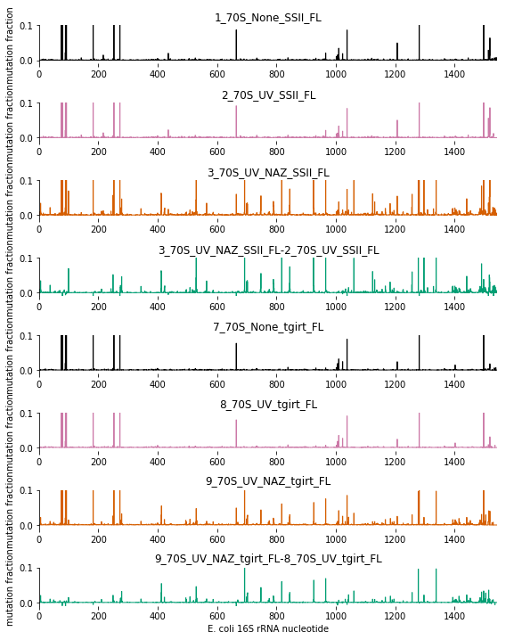

```python
import scipy.stats as stats
import math
import numpy

def plot_mutation_step(axis, lib_name, rRNA_name, start_position, end_position, color, subtract_background=False, alpha=1):
    library = ecoli_batch1_datasets.get_lib_from_name(lib_name)
    x = range(start_position, end_position+1)
    y = []
    for rRNA_position in x:
        nuc = library.get_nucleotide(rRNA_name, rRNA_position)
        if subtract_background:
            mutation_fraction = nuc.get_back_sub_mutation_rate()
        else:
            mutation_fraction = nuc.mutation_rate
        y.append(mutation_fraction)
    if subtract_background:
        axis.step(x, y, color=color,
                  label='%s-%s' % (library.lib_settings.sample_name, library.get_normalizing_lib().lib_settings.sample_name), lw=1, alpha=alpha)
        plot.set_title('%s-%s' % (library.lib_settings.sample_name, library.get_normalizing_lib().lib_settings.sample_name))
    else:
        axis.step(x, y, color=color, label='%s' % (library.lib_settings.sample_name), lw=1, alpha=alpha)
        plot.set_title('%s' % (library.lib_settings.sample_name))

    plot.set_ylim(-.01,.1)
    plot.set_xlim(start_position, end_position+1)
    plot.spines['right'].set_visible(False)
    plot.spines['top'].set_visible(False)
    plot.spines['bottom'].set_visible(False)
    plot.set_ylabel('mutation fraction')

rRNA = 'E.c.16S_rRNA'
start = 1
end = 1542
fig = plt.figure(figsize=(8,10))

colors = [mod_utils.black, mod_utils.reddishPurple, mod_utils.vermillion, mod_utils.bluishGreen]
plot_index = 1

lib_names = ['1_70S_None_SSII_FL', '2_70S_UV_SSII_FL','3_70S_UV_NAZ_SSII_FL']
for lib_name in lib_names:
    plot = fig.add_subplot(8, 1, plot_index)
    plot_mutation_step(plot, lib_name, rRNA , start, end, colors[(plot_index-1)%4], subtract_background=False)
    plot_index += 1
plot = fig.add_subplot(8, 1, plot_index)
plot_mutation_step(plot, lib_name, rRNA, start, end, colors[(plot_index-1)%4], subtract_background=True)
plot_index += 1

lib_names = ['7_70S_None_tgirt_FL', '8_70S_UV_tgirt_FL', '9_70S_UV_NAZ_tgirt_FL']
for lib_name in lib_names:
    plot = fig.add_subplot(8, 1, plot_index)
    plot_mutation_step(plot, lib_name, rRNA , start, end, colors[(plot_index-1)%4], subtract_background=False)
    plot_index += 1
plot = fig.add_subplot(8, 1, plot_index)
plot_mutation_step(plot, lib_name, rRNA, start, end, colors[(plot_index-1)%4], subtract_background=True)
plot_index += 1

plot.set_xlabel('E. coli 16S rRNA nucleotide')
plt.tight_layout()
plt.savefig('figure_S1_MaP_%s_%s.pdf' % (current_date(), current_time()), transparent='True', format='pdf')
```

### Figure S4: mutation traces across 18S rRNA for yeast samples

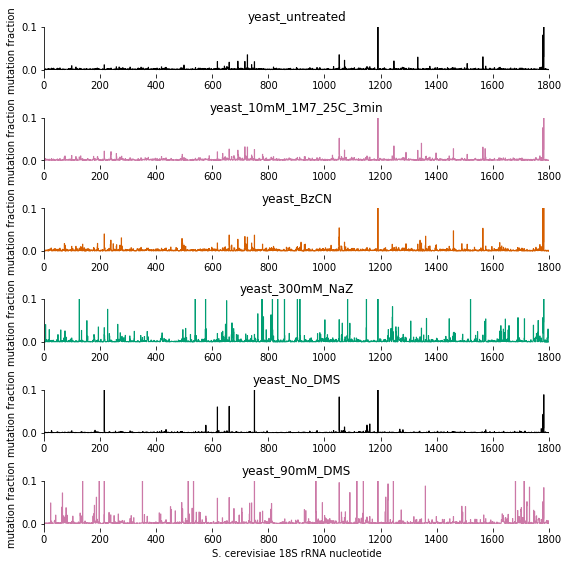

```python
import scipy.stats as stats
import math
import numpy

def plot_mutation_step(axis, lib_name, rRNA_name, start_position, end_position, color, subtract_background=False, alpha=1):
    library = scerevisiae_datasets.get_lib_from_name(lib_name)
    x = range(start_position, end_position+1)
    y = []
    for rRNA_position in x:
        nuc = library.get_nucleotide(rRNA_name, rRNA_position)
        if subtract_background:
            mutation_fraction = nuc.get_back_sub_mutation_rate()
        else:
            mutation_fraction = nuc.mutation_rate
        y.append(mutation_fraction)
    if subtract_background:
        axis.step(x, y, color=color,
                  label='%s-%s' % (library.lib_settings.sample_name, library.get_normalizing_lib().lib_settings.sample_name), lw=1, alpha=alpha)
        plot.set_title('%s-%s' % (library.lib_settings.sample_name, library.get_normalizing_lib().lib_settings.sample_name))
    else:
        axis.step(x, y, color=color, label='%s' % (library.lib_settings.sample_name), lw=1, alpha=alpha)
        plot.set_title('%s' % (library.lib_settings.sample_name))

    plot.set_ylim(-.01,.1)
    plot.set_xlim(start_position, end_position+1)
    plot.spines['right'].set_visible(False)
    plot.spines['top'].set_visible(False)
    plot.spines['bottom'].set_visible(False)
    plot.set_ylabel('mutation fraction')

rRNA = 'S.c.18S_rRNA'
start = 1
end = 1800
fig = plt.figure(figsize=(8,10))

colors = [mod_utils.black, mod_utils.reddishPurple, mod_utils.vermillion, mod_utils.bluishGreen]
plot_index = 1

lib_names = ['yeast_untreated', 'yeast_10mM_1M7_25C_3min','yeast_BzCN', 'yeast_300mM_NaZ', 'yeast_No_DMS', 'yeast_90mM_DMS']
for lib_name in lib_names:
    plot = fig.add_subplot(8, 1, plot_index)
    plot_mutation_step(plot, lib_name, rRNA , start, end, colors[(plot_index-1)%4], subtract_background=False)
    plot_index += 1

plot.set_xlabel('S. cerevisiae 18S rRNA nucleotide')
plt.tight_layout()
plt.savefig('figure_S4_cerevisiae_MaP_%s_%s.pdf' % (current_date(), current_time()), transparent='True', format='pdf')
```

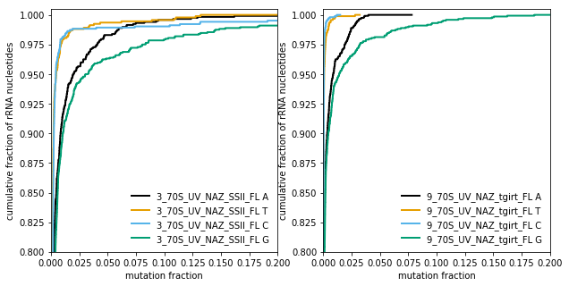

```python
#plot mutation CDF plots for E coli data
import scipy.stats as stats
import math
import numpy

colors = {'A':mod_utils.black, 'T':mod_utils.orange, 'C':mod_utils.skyBlue , 'G':mod_utils.bluishGreen }

fig = plt.figure(figsize=(10,5))

ax1 = fig.add_subplot(121)
for lib_name in ['3_70S_UV_NAZ_SSII_FL']:
    library = ecoli_batch1_datasets.get_lib_from_name(lib_name)
    for nuc in 'ATCG':
        mutations = [val for val in library.list_mutation_rates(subtract_background=False, subtract_control=False,
                                                        nucleotides_to_count=nuc,
                                                        exclude_constitutive=True)]
        n = numpy.arange(1,len(mutations)+1) / numpy.float(len(mutations))
        Xs = numpy.sort(mutations)
        ax1.step(Xs,n, color=colors[nuc],
                  label='%s %s' % (library.lib_settings.sample_name, nuc), lw=2)

ax1.set_ylabel('cumulative fraction of rRNA nucleotides')
ax1.set_xlabel('mutation fraction')
ax1.set_ylim(.80, 1.005)
ax1.set_xlim(0, 0.2)
lg=ax1.legend(loc=4)
lg.draw_frame(False)

ax1 = fig.add_subplot(122)
for lib_name in ['9_70S_UV_NAZ_tgirt_FL']:
    library = ecoli_batch1_datasets.get_lib_from_name(lib_name)
    for nuc in 'ATCG':
        mutations = [val for val in library.list_mutation_rates(subtract_background=True, subtract_control=False,
                                                        nucleotides_to_count=nuc,
                                                        exclude_constitutive=True)]
        n = numpy.arange(1,len(mutations)+1) / numpy.float(len(mutations))
        Xs = numpy.sort(mutations)
        ax1.step(Xs,n, color=colors[nuc],
                  label='%s %s' % (library.lib_settings.sample_name, nuc), lw=2)

ax1.set_ylabel('cumulative fraction of rRNA nucleotides')
ax1.set_xlabel('mutation fraction')
#ax1.set_xscale('log')
ax1.set_ylim(.80, 1.005)
ax1.set_xlim(0, 0.2)
lg=ax1.legend(loc=4)
lg.draw_frame(False)

plt.savefig('Figure_S3A_back_sub_e_coli_misincorp_cdf_%s_%s.pdf' % (current_date(), current_time()), transparent='True', format='pdf')
```

## Figure S3B: CDF of background-subtracted RT stop RPM

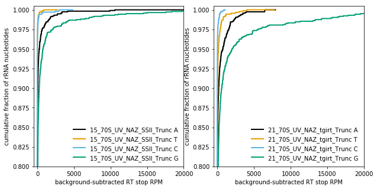

```python
import scipy.stats as stats
import math
import numpy

#Makes cdf plots of raw mutation rates
colors = {'A':mod_utils.black, 'T':mod_utils.orange, 'C':mod_utils.skyBlue , 'G':mod_utils.bluishGreen }

fig = plt.figure(figsize=(10, 5))

ax1 = fig.add_subplot(121)
for lib_name in ['15_70S_UV_NAZ_SSII_Trunc']:
    library = ecoli_batch1_datasets.get_lib_from_name(lib_name)
    for nuc in 'ATCG':
        mutations = [val for val in library.list_rt_stop_rpms(subtract_background=True, subtract_control=False,
                                                        nucleotides_to_count=nuc,
                                                        exclude_constitutive=True)]
        n = numpy.arange(1,len(mutations)+1) / numpy.float(len(mutations))
        Xs = numpy.sort(mutations)
        ax1.step(Xs,n, color=colors[nuc],
                  label='%s %s' % (library.lib_settings.sample_name, nuc), lw=2)

ax1.set_ylabel('cumulative fraction of rRNA nucleotides')
ax1.set_xlabel('background-subtracted RT stop RPM')
#ax1.set_xscale('log')
ax1.set_ylim(.8, 1.005)
ax1.set_xlim(-500, 20000)
lg=ax1.legend(loc=4)
lg.draw_frame(False)

ax1 = fig.add_subplot(122)
for lib_name in ['21_70S_UV_NAZ_tgirt_Trunc']:
    library = ecoli_batch1_datasets.get_lib_from_name(lib_name)
    for nuc in 'ATCG':
        mutations = [val for val in library.list_rt_stop_rpms(subtract_background=True, subtract_control=False,
                                                        nucleotides_to_count=nuc,
                                                        exclude_constitutive=True)]
        n = numpy.arange(1,len(mutations)+1) / numpy.float(len(mutations))
        Xs = numpy.sort(mutations)
        ax1.step(Xs,n, color=colors[nuc],
                  label='%s %s' % (library.lib_settings.sample_name, nuc), lw=2)

ax1.set_ylabel('cumulative fraction of rRNA nucleotides')
ax1.set_xlabel('background-subtracted RT stop RPM')
#ax1.set_xscale('log')
ax1.set_ylim(.8, 1.005)
ax1.set_xlim(-500, 20000)
lg=ax1.legend(loc=4)
lg.draw_frame(False)

plt.savefig('FigureS3B_e_coli_back_sub_rt_stop_cdf_%s_%s.pdf' % (current_date(), current_time()), transparent='True', format='pdf')
```

## Figure S3C: Correlation between misincorporation replicates. with/without bground subtraction

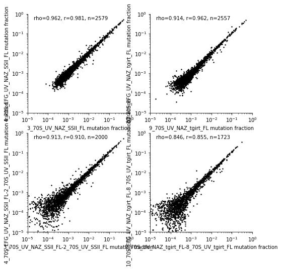

```python
import scipy.stats as stats
import numpy as np
def plot_correlation(axis, experiment, lib_nameX, lib_nameY, nucs_to_include='ATCG', color=mod_utils.black,
                     subtract_background=False, exclude_constitutive=True):
    x = []
    y = []
    libX = experiment.get_lib_from_name(lib_nameX)
    libY = experiment.get_lib_from_name(lib_nameY)
    for rRNA_name in libX.rRNA_mutation_data:
        for position in libX.rRNA_mutation_data[rRNA_name].nucleotides:
            nucX = libX.get_nucleotide(rRNA_name, position)
            nucY = libY.get_nucleotide(rRNA_name, position)
            if libX.get_nucleotide(rRNA_name, position).identity in 'AG' and not (exclude_constitutive and nucX.exclude_constitutive):
                if subtract_background:
                    valX = nucX.get_back_sub_mutation_rate()
                    valY = nucY.get_back_sub_mutation_rate()
                else:
                    valX = nucX.mutation_rate
                    valY = nucY.mutation_rate
                if valX>0 and valY>0:
                    x.append(valX)
                    y.append(valY)
    plot.scatter(x, y, color=color, s=2)
    rho, p = stats.spearmanr(np.log10(np.array(x)), np.log10(np.array(y)))
    r, p = stats.pearsonr(np.log10(np.array(x)), np.log10(np.array(y)))
    if subtract_background:
        plot.set_xlabel("%s-%s mutation fraction" % (lib_nameX, libX.get_normalizing_lib().lib_settings.sample_name))
        plot.set_ylabel("%s-%s mutation fraction" % (lib_nameY, libY.get_normalizing_lib().lib_settings.sample_name))
    else:
        plot.set_xlabel("%s mutation fraction" % (lib_nameX))
        plot.set_ylabel("%s mutation fraction" % (lib_nameY))
    plot.set_yscale('log')
    plot.set_xscale('log')
    plot.spines['right'].set_visible(False)
    plot.spines['top'].set_visible(False)
    plot.annotate('rho=%.3f, r=%.3f, n=%d' % (rho, r, len(x)), xy=(.00002, .5), xytext=(.00002, .5))
    plot.set_xlim(.00001,1)
    plot.set_ylim(.00001,1)

fig = plt.figure(figsize=(8,8))
colors = [mod_utils.black, mod_utils.reddishPurple, mod_utils.vermillion, mod_utils.bluishGreen]

plot = fig.add_subplot(221)
plot_correlation(plot, ecoli_batch1_datasets, '3_70S_UV_NAZ_SSII_FL', '4_70S_EFG_UV_NAZ_SSII_FL', nucs_to_include='AG', subtract_background=False)
plot = fig.add_subplot(222)
plot_correlation(plot, ecoli_batch1_datasets, '9_70S_UV_NAZ_tgirt_FL', '10_70S_EFG_UV_NAZ_tgirt_FL', nucs_to_include='AG', subtract_background=False)
plot = fig.add_subplot(223)
plot_correlation(plot, ecoli_batch1_datasets, '3_70S_UV_NAZ_SSII_FL', '4_70S_EFG_UV_NAZ_SSII_FL', nucs_to_include='AG', subtract_background=True)
plot = fig.add_subplot(224)
plot_correlation(plot, ecoli_batch1_datasets, '9_70S_UV_NAZ_tgirt_FL', '10_70S_EFG_UV_NAZ_tgirt_FL', nucs_to_include='AG', subtract_background=True)
#plt.tight_layout()


plt.savefig('Figure_S3C_mutation_reps_AG_only_%s_%s.pdf' % (current_date(), current_time()), transparent='True', format='pdf')
```

## Figure S3D: Correlation between RT stop replicates. with/without bground subtraction

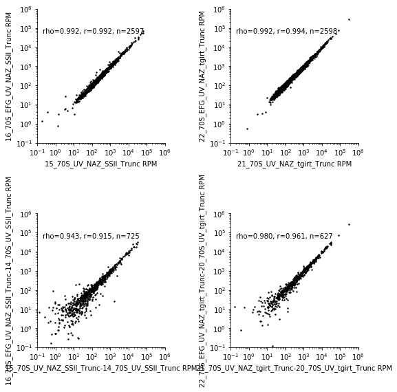

```python
import scipy.stats as stats
import numpy as np
def plot_correlation(axis, experiment, lib_nameX, lib_nameY, nucs_to_include='ATCG', color=mod_utils.black,
                     subtract_background=False, exclude_constitutive=True):
    x = []
    y = []
    libX = ecoli_batch1_datasets.get_lib_from_name(lib_nameX)
    libY = ecoli_batch1_datasets.get_lib_from_name(lib_nameY)
    for rRNA_name in libX.rRNA_mutation_data:
        for position in libX.rRNA_mutation_data[rRNA_name].nucleotides:
            nucX = libX.get_nucleotide(rRNA_name, position)
            nucY = libY.get_nucleotide(rRNA_name, position)
            if libX.get_nucleotide(rRNA_name, position).identity in 'AG' and not (exclude_constitutive and nucX.exclude_constitutive):
                if subtract_background:
                    valX = nucX.get_rt_stop_rpm()-nucX.get_background_nucleotide().get_rt_stop_rpm()
                    valY = nucY.get_rt_stop_rpm()-nucY.get_background_nucleotide().get_rt_stop_rpm()
                else:
                    valX = nucX.get_rt_stop_rpm()
                    valY = nucY.get_rt_stop_rpm()
                if valX>0 and valY>0:
                    x.append(valX)
                    y.append(valY)
    plot.scatter(x, y, color=color, s=2)
    rho, p = stats.spearmanr(np.log10(np.array(x)), np.log10(np.array(y)))
    r, p = stats.pearsonr(np.log10(np.array(x)), np.log10(np.array(y)))
    if subtract_background:
        plot.set_xlabel("%s-%s RPM" % (lib_nameX, libX.get_normalizing_lib().lib_settings.sample_name))
        plot.set_ylabel("%s-%s RPM" % (lib_nameY, libY.get_normalizing_lib().lib_settings.sample_name))
    else:
        plot.set_xlabel("%s RPM" % (lib_nameX))
        plot.set_ylabel("%s RPM" % (lib_nameY))
    plot.set_yscale('log')
    plot.set_xscale('log')
    plot.spines['right'].set_visible(False)
    plot.spines['top'].set_visible(False)
    plot.annotate('rho=%.3f, r=%.3f, n=%d' % (rho, r, len(x)), xy=(.2, 50000), xytext=(.2, 50000))
    plot.set_xlim(.1,1000000)
    plot.set_ylim(.1,1000000)

fig = plt.figure(figsize=(8,8))
colors = [mod_utils.black, mod_utils.reddishPurple, mod_utils.vermillion, mod_utils.bluishGreen]

plot = fig.add_subplot(221)
plot_correlation(plot, ecoli_batch1_datasets, '15_70S_UV_NAZ_SSII_Trunc', '16_70S_EFG_UV_NAZ_SSII_Trunc', nucs_to_include='AG', subtract_background=False)
plot = fig.add_subplot(222)
plot_correlation(plot, ecoli_batch1_datasets, '21_70S_UV_NAZ_tgirt_Trunc', '22_70S_EFG_UV_NAZ_tgirt_Trunc', nucs_to_include='AG', subtract_background=False)
plot = fig.add_subplot(223)
plot_correlation(plot, ecoli_batch1_datasets, '15_70S_UV_NAZ_SSII_Trunc', '16_70S_EFG_UV_NAZ_SSII_Trunc', nucs_to_include='AG', subtract_background=True)
plot = fig.add_subplot(224)
plot_correlation(plot, ecoli_batch1_datasets, '21_70S_UV_NAZ_tgirt_Trunc', '22_70S_EFG_UV_NAZ_tgirt_Trunc', nucs_to_include='AG', subtract_background=True)
plt.tight_layout()


plt.savefig('Figure_S3D_RT_stop_reps_AG_only_%s_%s.pdf' % (current_date(), current_time()), transparent='True', format='pdf')
```

Note: the single point at the upper-right of the TGIRT plot is from G41 in the 5S rRNA, which has 300,000 RPM upon NAz treatment

## Figure S3E: Correlation between RTs for RT stops and mutations with bground subtraction

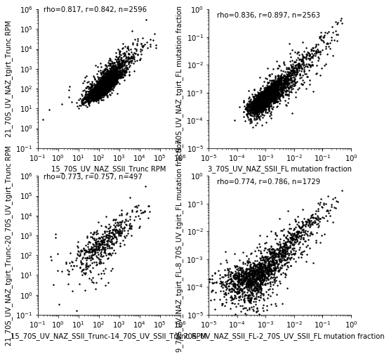

```python
import scipy.stats as stats
import numpy as np
def plot_RT_correlation(axis, experiment, lib_nameX, lib_nameY, nucs_to_include='ATCG', color=mod_utils.black,
                     subtract_background=False, exclude_constitutive=True):
    x = []
    y = []
    libX = experiment.get_lib_from_name(lib_nameX)
    libY = experiment.get_lib_from_name(lib_nameY)
    for rRNA_name in libX.rRNA_mutation_data:
        for position in libX.rRNA_mutation_data[rRNA_name].nucleotides:
            nucX = libX.get_nucleotide(rRNA_name, position)
            nucY = libY.get_nucleotide(rRNA_name, position)
            if libX.get_nucleotide(rRNA_name, position).identity in 'AG' and not (exclude_constitutive and nucX.exclude_constitutive):
                if subtract_background:
                    valX = nucX.get_rt_stop_rpm()-nucX.get_background_nucleotide().get_rt_stop_rpm()
                    valY = nucY.get_rt_stop_rpm()-nucY.get_background_nucleotide().get_rt_stop_rpm()
                else:
                    valX = nucX.get_rt_stop_rpm()
                    valY = nucY.get_rt_stop_rpm()
                if valX>0 and valY>0:
                    x.append(valX)
                    y.append(valY)
    plot.scatter(x, y, color=color, s=2)
    rho, p = stats.spearmanr(np.log10(np.array(x)), np.log10(np.array(y)))
    r, p = stats.pearsonr(np.log10(np.array(x)), np.log10(np.array(y)))
    if subtract_background:
        plot.set_xlabel("%s-%s RPM" % (lib_nameX, libX.get_normalizing_lib().lib_settings.sample_name))
        plot.set_ylabel("%s-%s RPM" % (lib_nameY, libY.get_normalizing_lib().lib_settings.sample_name))
    else:
        plot.set_xlabel("%s RPM" % (lib_nameX))
        plot.set_ylabel("%s RPM" % (lib_nameY))
    plot.set_yscale('log')
    plot.set_xscale('log')
    plot.spines['right'].set_visible(False)
    plot.spines['top'].set_visible(False)
    plot.annotate('rho=%.3f, r=%.3f, n=%d' % (rho, r, len(x)), xy=(.2, 700000), xytext=(.2, 700000))
    plot.set_xlim(.1,1000000)
    plot.set_ylim(.1,1000000)

def plot_MaP_correlation(axis, experiment, lib_nameX, lib_nameY, nucs_to_include='ATCG', color=mod_utils.black,
                     subtract_background=False, exclude_constitutive=True):
    x = []
    y = []
    libX = experiment.get_lib_from_name(lib_nameX)
    libY = experiment.get_lib_from_name(lib_nameY)
    for rRNA_name in libX.rRNA_mutation_data:
        for position in libX.rRNA_mutation_data[rRNA_name].nucleotides:
            nucX = libX.get_nucleotide(rRNA_name, position)
            nucY = libY.get_nucleotide(rRNA_name, position)
            if libX.get_nucleotide(rRNA_name, position).identity in 'AG' and not (exclude_constitutive and nucX.exclude_constitutive):
                if subtract_background:
                    valX = nucX.get_back_sub_mutation_rate()
                    valY = nucY.get_back_sub_mutation_rate()
                else:
                    valX = nucX.mutation_rate
                    valY = nucY.mutation_rate
                if valX>0 and valY>0:
                    x.append(valX)
                    y.append(valY)
    plot.scatter(x, y, color=color, s=2)
    rho, p = stats.spearmanr(np.log10(np.array(x)), np.log10(np.array(y)))
    r, p = stats.pearsonr(np.log10(np.array(x)), np.log10(np.array(y)))
    if subtract_background:
        plot.set_xlabel("%s-%s mutation fraction" % (lib_nameX, libX.get_normalizing_lib().lib_settings.sample_name))
        plot.set_ylabel("%s-%s mutation fraction" % (lib_nameY, libY.get_normalizing_lib().lib_settings.sample_name))
    else:
        plot.set_xlabel("%s mutation fraction" % (lib_nameX))
        plot.set_ylabel("%s mutation fraction" % (lib_nameY))
    plot.set_yscale('log')
    plot.set_xscale('log')
    plot.spines['right'].set_visible(False)
    plot.spines['top'].set_visible(False)
    plot.annotate('rho=%.3f, r=%.3f, n=%d' % (rho, r, len(x)), xy=(.00002, .5), xytext=(.00002, .5))
    plot.set_xlim(.00001,1)
    plot.set_ylim(.00001,1)

fig = plt.figure(figsize=(8,8))
colors = [mod_utils.black, mod_utils.reddishPurple, mod_utils.vermillion, mod_utils.bluishGreen]

plot = fig.add_subplot(221)
plot_RT_correlation(plot, ecoli_batch1_datasets, '15_70S_UV_NAZ_SSII_Trunc', '21_70S_UV_NAZ_tgirt_Trunc', nucs_to_include='AG', subtract_background=False)
plot = fig.add_subplot(222)
plot_MaP_correlation(plot, ecoli_batch1_datasets, '3_70S_UV_NAZ_SSII_FL', '9_70S_UV_NAZ_tgirt_FL', nucs_to_include='AG', subtract_background=False)
plot = fig.add_subplot(223)
plot_RT_correlation(plot, ecoli_batch1_datasets, '15_70S_UV_NAZ_SSII_Trunc', '21_70S_UV_NAZ_tgirt_Trunc', nucs_to_include='AG', subtract_background=True)
plot = fig.add_subplot(224)
plot_MaP_correlation(plot, ecoli_batch1_datasets, '3_70S_UV_NAZ_SSII_FL', '9_70S_UV_NAZ_tgirt_FL', nucs_to_include='AG', subtract_background=True)
#plt.tight_layout()


plt.savefig('Figure_S3E_AG_only_SSII_vs_TGIRTIII_%s_%s.pdf' % (current_date(), current_time()), transparent='True', format='pdf')
```

## Figure S3F: Correlation between mutatations and RT stops with bground subtraction

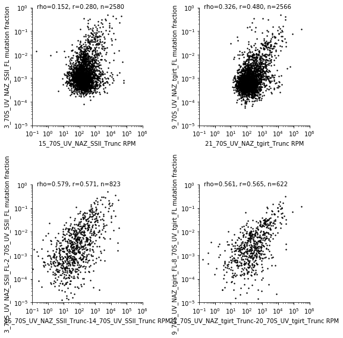

```python
import scipy.stats as stats
import numpy as np
def plot_RT_MaP_correlation(axis, experiment, lib_nameX, lib_nameY, nucs_to_include='ATCG', color=mod_utils.black,
                     subtract_background=False, exclude_constitutive=True):
    x = []
    y = []
    libX = experiment.get_lib_from_name(lib_nameX)
    libY = experiment.get_lib_from_name(lib_nameY)
    for rRNA_name in libX.rRNA_mutation_data:
        for position in libX.rRNA_mutation_data[rRNA_name].nucleotides:
            nucX = libX.get_nucleotide(rRNA_name, position)
            nucY = libY.get_nucleotide(rRNA_name, position)
            if libX.get_nucleotide(rRNA_name, position).identity in 'AG' and not (exclude_constitutive and nucX.exclude_constitutive):
                if subtract_background:
                    valX = nucX.get_rt_stop_rpm()-nucX.get_background_nucleotide().get_rt_stop_rpm()
                    valY = nucY.get_back_sub_mutation_rate()
                else:
                    valX = nucX.get_rt_stop_rpm()
                    valY = nucY.mutation_rate
                if valX>0 and valY>0:
                    x.append(valX)
                    y.append(valY)
    plot.scatter(x, y, color=color, s=2)
    rho, p = stats.spearmanr(np.log10(np.array(x)), np.log10(np.array(y)))
    r, p = stats.pearsonr(np.log10(np.array(x)), np.log10(np.array(y)))
    if subtract_background:
        plot.set_xlabel("%s-%s RPM" % (lib_nameX, libX.get_normalizing_lib().lib_settings.sample_name))
        plot.set_ylabel("%s-%s mutation fraction" % (lib_nameY, libY.get_normalizing_lib().lib_settings.sample_name))
    else:
        plot.set_xlabel("%s RPM" % (lib_nameX))
        plot.set_ylabel("%s mutation fraction" % (lib_nameY))
    plot.set_yscale('log')
    plot.set_xscale('log')
    plot.spines['right'].set_visible(False)
    plot.spines['top'].set_visible(False)
    plot.annotate('rho=%.3f, r=%.3f, n=%d' % (rho, r, len(x)), xy=(.2, .9), xytext=(.2, .9))
    plot.set_xlim(.1,1000000)
    plot.set_ylim(.00001,1)

fig = plt.figure(figsize=(8,8))
colors = [mod_utils.black, mod_utils.reddishPurple, mod_utils.vermillion, mod_utils.bluishGreen]

plot = fig.add_subplot(221)
plot_RT_MaP_correlation(plot, ecoli_batch1_datasets, '15_70S_UV_NAZ_SSII_Trunc', '3_70S_UV_NAZ_SSII_FL', nucs_to_include='AG', subtract_background=False)
plot = fig.add_subplot(222)
plot_RT_MaP_correlation(plot, ecoli_batch1_datasets, '21_70S_UV_NAZ_tgirt_Trunc', '9_70S_UV_NAZ_tgirt_FL', nucs_to_include='AG', subtract_background=False)
plot = fig.add_subplot(223)
plot_RT_MaP_correlation(plot, ecoli_batch1_datasets, '15_70S_UV_NAZ_SSII_Trunc', '3_70S_UV_NAZ_SSII_FL', nucs_to_include='AG', subtract_background=True)
plot = fig.add_subplot(224)
plot_RT_MaP_correlation(plot, ecoli_batch1_datasets, '21_70S_UV_NAZ_tgirt_Trunc', '9_70S_UV_NAZ_tgirt_FL', nucs_to_include='AG', subtract_background=True)
plt.tight_layout()


plt.savefig('figure_S3F_mut_vs_RT_AGonly_%s_%s.pdf' % (current_date(), current_time()), transparent='True', format='pdf')
```

## Figure 4A&C and S7A: Step plots of mutation fold changes on 23S rRNA upon EFG binding

## significance calls using Weeks lab method

```python
#plot mutation CDF plots for E coli data
import scipy.stats as stats
import math
import numpy

lib_names = ['4_70S_EFG_UV_NAZ_SSII_FL', '5_70S_EFG_GDPNP_UV_NAZ_SSII_FL',  '10_70S_EFG_UV_NAZ_tgirt_FL', '11_70S_EFG_GDPNP_UV_NAZ_tgirt_FL']

def make_sig_change_calls(lib_name):
    library = ecoli_batch1_datasets.get_lib_from_name(lib_name)
    #compute normalization factors
    exp_mutations = []
    ctrl_mutations = []
    for rRNA_name in library.rRNA_mutation_data.keys():
        for rRNA_position in sorted(library.rRNA_mutation_data[rRNA_name].nucleotides.keys()):
            nuc = library.get_nucleotide(rRNA_name, rRNA_position)
            if nuc.identity in 'AG':
                exp_mutations.append(nuc.mutation_rate)
                ctrl_mutations.append(nuc.get_control_nucleotide().mutation_rate)
    exp_norm = numpy.mean(exp_mutations)
    ctrl_norm = numpy.mean(ctrl_mutations)

    protections = {}
    deprotections = {}
    for rRNA_name in library.rRNA_mutation_data.keys():
        positions = []
        reactivity_deltas = []
        z_factors = []
        for rRNA_position in sorted(library.rRNA_mutation_data[rRNA_name].nucleotides.keys()):
            nuc = library.get_nucleotide(rRNA_name, rRNA_position)
            if nuc.identity in 'AG' and not nuc.exclude_constitutive:
                positions.append(rRNA_position)
                control_sub=(nuc.mutation_rate/exp_norm) - (nuc.get_control_nucleotide().mutation_rate/ctrl_norm)
                reactivity_deltas.append(control_sub)
                exp_error = nuc.get_error()/exp_norm
                ctrl_error = nuc.get_control_nucleotide().get_error()/ctrl_norm
                z = 1-(1.99*(exp_error+ctrl_error)/abs(control_sub))
                z_factors.append(z)
        reactivity_delta_mean = numpy.mean(reactivity_deltas)
        reactivity_delta_std = numpy.std(reactivity_deltas)
        scores = (numpy.array(reactivity_deltas)-reactivity_delta_mean)/reactivity_delta_std
        protections[rRNA_name] = [positions[i] for i in range(len(positions)) if abs(scores[i])>0 and z_factors[i]>0 and reactivity_deltas[i]<0]
        deprotections[rRNA_name] = [positions[i] for i in range(len(positions)) if abs(scores[i])>0 and z_factors[i]>0 and reactivity_deltas[i]>0]
    return protections, deprotections

all_prot_calls = {}
all_deprot_calls = {}
for lib_name in lib_names:
   all_prot_calls[lib_name], all_deprot_calls[lib_name] = make_sig_change_calls(lib_name)
```

```python
common_prot_calls = {}
common_deprot_calls = {}
out_file = open('tableS2_prot_calls_%s_%s.tsv' % (current_date(), current_time()), 'w')
out_file.write('nucleotide\tsamples with significant change\tchange type\tnumber of samples\n')
rRNAs = ['E.c.23S_rRNA', 'E.c.5S___rRNA', 'E.c.16S_rRNA']
lib_names = ['4_70S_EFG_UV_NAZ_SSII_FL', '5_70S_EFG_GDPNP_UV_NAZ_SSII_FL',  '10_70S_EFG_UV_NAZ_tgirt_FL', '11_70S_EFG_GDPNP_UV_NAZ_tgirt_FL']
num_libs_to_call = 4
for rRNA in rRNAs:
    common_prot_calls[rRNA]=[]
    common_deprot_calls[rRNA]=[]
    for i in range(3500):
        protected_libs = []
        for lib_name in lib_names:
            if i in all_prot_calls[lib_name][rRNA]:
                protected_libs.append(lib_name)
        if len(protected_libs)>0:
            library = ecoli_batch1_datasets.get_lib_from_name(lib_name)
            nuc = library.get_nucleotide(rRNA, i)
            out_file.write('%s_%d%s\t%s\tprotected\t%d\n' % (rRNA, i, nuc.identity, ','.join(protected_libs), len(protected_libs)))
        if len(protected_libs) >= num_libs_to_call:
            common_prot_calls[rRNA].append(i)

        deprotected_libs = []
        for lib_name in lib_names:
            if i in all_deprot_calls[lib_name][rRNA]:
                deprotected_libs.append(lib_name)
        if len(deprotected_libs)>0:
            library = ecoli_batch1_datasets.get_lib_from_name(lib_name)
            nuc = library.get_nucleotide(rRNA, i)
            out_file.write('%s_%d%s\t%s\tdeprotected\t%d\n' % (rRNA, i, nuc.identity, ','.join(deprotected_libs), len(deprotected_libs)))
        if len(deprotected_libs) >= num_libs_to_call:
            common_deprot_calls[rRNA].append(i)
out_file.close()
```

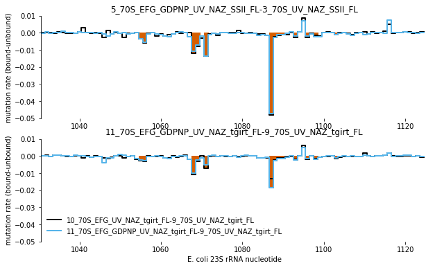

```python
import scipy.stats as stats
import math
import numpy

def plot_mutation_change_step(axis, lib_name, rRNA_name, start_position, end_position, color,
                              protection_color, deprotection_color, protected_pos, deprotected_pos, alpha=1, ymin=-0.05, ymax =0.01, linestyle='-'):
    library = ecoli_batch1_datasets.get_lib_from_name(lib_name)


    x = range(start_position, end_position+1)
    y = []
    for rRNA_position in x:
        nuc = library.get_nucleotide(rRNA_name, rRNA_position)
        control_sub=nuc.get_control_sub_mutation_rate()
        y.append(control_sub)
        if rRNA_position in protected_pos[rRNA_name]:
            plot.fill_between([rRNA_position-1, rRNA_position], [control_sub, control_sub], step="pre", alpha=1, color=protection_color)
        if rRNA_position in deprotected_pos[rRNA_name]:
            plot.fill_between([rRNA_position-1, rRNA_position], [control_sub, control_sub], step="pre", alpha=1, color=deprotection_color)
    axis.step(x, y, color=color, label='%s-%s' % (library.lib_settings.sample_name, library.get_normalizing_lib_with_mod().lib_settings.sample_name),
              lw=2, alpha=alpha, linestyle=linestyle)
    plot.set_title('%s-%s' % (library.lib_settings.sample_name, library.get_normalizing_lib_with_mod().lib_settings.sample_name))
    plot.set_ylim(ymin,ymax)
    #plot.axhline(y=0, linestyle='dashed')
    plot.spines['right'].set_visible(False)
    plot.spines['top'].set_visible(False)
    plot.spines['bottom'].set_visible(False)
    plot.set_ylabel('mutation rate (bound-unbound)')


rRNA = 'E.c.23S_rRNA'
start = 1030
end = 1124
fig = plt.figure(figsize=(10,6))
plot = fig.add_subplot(211)
plot_mutation_change_step(plot, '4_70S_EFG_UV_NAZ_SSII_FL', rRNA, start, end, mod_utils.black, mod_utils.vermillion, mod_utils.bluishGreen,
                          common_prot_calls, common_deprot_calls)
#plot = fig.add_subplot(412)
plot_mutation_change_step(plot, '5_70S_EFG_GDPNP_UV_NAZ_SSII_FL', rRNA, start, end, mod_utils.skyBlue, mod_utils.vermillion, mod_utils.bluishGreen,
                          common_prot_calls, common_deprot_calls)
ticks = plot.get_xticks()
plot.set_xticks(ticks-.5)
plot.set_xticklabels([int(tick) for tick in ticks])
plot.set_xlim(start, end+1)
plot = fig.add_subplot(212)
plot_mutation_change_step(plot, '10_70S_EFG_UV_NAZ_tgirt_FL', rRNA, start, end, mod_utils.black, mod_utils.vermillion, mod_utils.bluishGreen,
                          common_prot_calls, common_deprot_calls)
plot_mutation_change_step(plot, '11_70S_EFG_GDPNP_UV_NAZ_tgirt_FL', rRNA, start, end, mod_utils.skyBlue, mod_utils.vermillion, mod_utils.bluishGreen,
                          common_prot_calls, common_deprot_calls)
ticks = plot.get_xticks()
plot.set_xticks(ticks-.5)
plot.set_xticklabels([int(tick) for tick in ticks])
plot.set_xlim(start, end+1)

lg=plot.legend(loc=3)
lg.draw_frame(False)
plot.set_xlabel('E. coli 23S rRNA nucleotide')
plt.savefig('Figure_4C_GAR_detail_%s_%s.pdf' % (current_date(), current_time()), transparent='True', format='pdf')
```

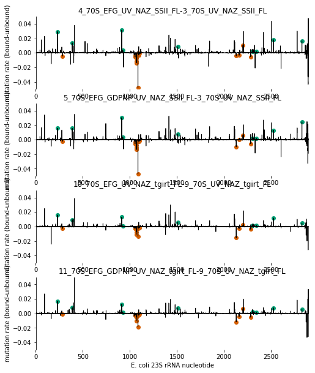

```python
import scipy.stats as stats
import math
import numpy

def plot_mutation_change_step(axis, lib_name, rRNA_name, start_position, end_position, color,
                              protection_color, deprotection_color, protected_pos, deprotected_pos, alpha=1, ymin=-0.05,
                              ymax =0.05, linestyle='-'):
    library = ecoli_batch1_datasets.get_lib_from_name(lib_name)
    x = range(start_position, end_position+1)
    y = []
    proX = []
    proY = []
    deproX = []
    deproY = []
    for rRNA_position in x:
        nuc = library.get_nucleotide(rRNA_name, rRNA_position)
        control_sub=nuc.get_control_sub_mutation_rate()
        y.append(control_sub)
        if rRNA_position in protected_pos[rRNA_name]:
            proX.append(rRNA_position)
            proY.append(control_sub)
        if rRNA_position in deprotected_pos[rRNA_name]:
            deproX.append(rRNA_position)
            deproY.append(control_sub)

    axis.step(x, y, color=color,
              lw=1, alpha=alpha, linestyle=linestyle)
    axis.scatter(proX, proY, color = protection_color, alpha = 1)
    axis.scatter(deproX, deproY, color = deprotection_color, alpha = 1)
    plot.set_title('%s-%s' % (library.lib_settings.sample_name, library.get_normalizing_lib_with_mod().lib_settings.sample_name))
    plot.set_ylim(ymin,ymax)
    #plot.axhline(y=0, linestyle='dashed')
    ticks = plot.get_xticks()
    plot.set_xticks(ticks-.5)
    plot.set_xticklabels([int(tick) for tick in ticks])
    plot.set_xlim(start_position, end_position+1)
    plot.spines['right'].set_visible(False)
    plot.spines['top'].set_visible(False)
    plot.spines['bottom'].set_visible(False)
    plot.set_ylabel('mutation rate (bound-unbound)')


rRNA = 'E.c.23S_rRNA'
start = 1
end = 2904
fig = plt.figure(figsize=(8,10))
plot = fig.add_subplot(411)
plot_mutation_change_step(plot, '4_70S_EFG_UV_NAZ_SSII_FL', rRNA, start, end, mod_utils.black, mod_utils.vermillion, mod_utils.bluishGreen,
                          common_prot_calls, common_deprot_calls)
plot = fig.add_subplot(412)
plot_mutation_change_step(plot, '5_70S_EFG_GDPNP_UV_NAZ_SSII_FL', rRNA, start, end, mod_utils.black, mod_utils.vermillion, mod_utils.bluishGreen,
                          common_prot_calls, common_deprot_calls)
plot = fig.add_subplot(413)
plot_mutation_change_step(plot, '10_70S_EFG_UV_NAZ_tgirt_FL', rRNA, start, end, mod_utils.black, mod_utils.vermillion, mod_utils.bluishGreen,
                          common_prot_calls, common_deprot_calls)
plot = fig.add_subplot(414)
plot_mutation_change_step(plot, '11_70S_EFG_GDPNP_UV_NAZ_tgirt_FL', rRNA, start, end, mod_utils.black, mod_utils.vermillion, mod_utils.bluishGreen,
                          common_prot_calls, common_deprot_calls)
plot.set_xlabel('E. coli 23S rRNA nucleotide')
plt.savefig('figure_4A_S7A_23S_smola_calls_%s_%s.pdf' % (current_date(), current_time()), transparent='True', format='pdf')
```

### Make MA plots with significant changes highlight

```
0.00784003315704 0.00731613878345
0.00785834403154 0.00731613878345
0.0049339006081 0.00460313532651
0.00495520996426 0.00460313532651
```

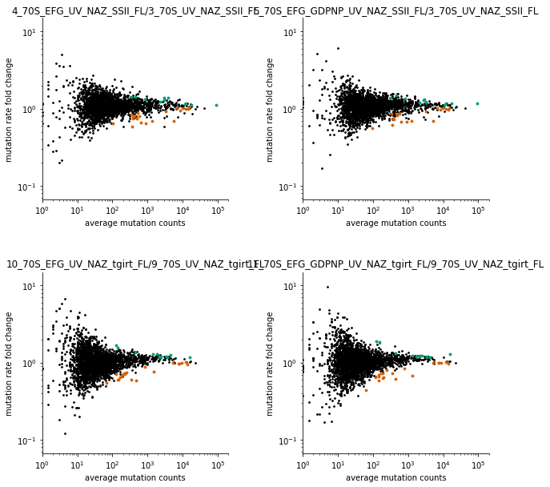

```python
import scipy.stats as stats
import math
import numpy

def plot_MA(axis, lib_name, protected_pos, deprotected_pos):
    library = ecoli_batch1_datasets.get_lib_from_name(lib_name)
    #compute normalization factors
    exp_mutations = []
    ctrl_mutations = []
    for rRNA_name in library.rRNA_mutation_data.keys():
        for rRNA_position in sorted(library.rRNA_mutation_data[rRNA_name].nucleotides.keys()):
            nuc = library.get_nucleotide(rRNA_name, rRNA_position)
            if nuc.identity in 'AG':
                exp_mutations.append(nuc.mutation_rate)
                ctrl_mutations.append(nuc.get_control_nucleotide().mutation_rate)
    exp_norm = numpy.mean(exp_mutations)
    ctrl_norm = numpy.mean(ctrl_mutations)
    print exp_norm, ctrl_norm




    x = []
    y = []
    proX = []
    proY = []
    deproX = []
    deproY = []
    for rRNA_name in library.rRNA_mutation_data.keys():
        for rRNA_position in sorted(library.rRNA_mutation_data[rRNA_name].nucleotides):
            nuc = library.get_nucleotide(rRNA_name, rRNA_position)
            if nuc.identity in 'AG':
                control_fold_change = nuc.get_control_fold_change_in_mutation_rate()
                #control_fold_change = nuc.get_control_fold_change_in_mutation_rate()*ctrl_norm/exp_norm
                avg_mutation_counts = (nuc.total_mutation_counts+nuc.get_control_nucleotide().total_mutation_counts)/2.0
                if rRNA_position in protected_pos[rRNA_name]:
                    proX.append(avg_mutation_counts)
                    proY.append(control_fold_change)
                elif rRNA_position in deprotected_pos[rRNA_name]:
                    deproX.append(avg_mutation_counts)
                    deproY.append(control_fold_change)
                else:
                    x.append(avg_mutation_counts)
                    y.append(control_fold_change)
    plot.scatter(x, y, color=mod_utils.black, s=3)
    plot.scatter(proX, proY, color = mod_utils.vermillion, s=8)
    plot.scatter(deproX, deproY, color = mod_utils.bluishGreen, s=8)
    plot.set_title('%s/%s' % (library.lib_settings.sample_name, library.get_normalizing_lib_with_mod().lib_settings.sample_name))
    ticks = plot.get_xticks()
    plot.set_xticks(ticks-.5)
    plot.set_xticklabels([int(tick) for tick in ticks])

    plot.spines['right'].set_visible(False)
    plot.spines['top'].set_visible(False)
    plot.set_ylabel('mutation rate fold change')
    plot.set_xlabel('average mutation counts')
    plot.set_yscale('log')
    plot.set_xscale('log')
    #plot.axhline(y=1, linestyle='dashed')

    plot.set_xlim(1,200000)
    plot.set_ylim(1/15.,15)


fig = plt.figure(figsize=(10,10))
fig.subplots_adjust(wspace=0.4, hspace=0.4)
plot = fig.add_subplot(221)
plot_MA(plot, '4_70S_EFG_UV_NAZ_SSII_FL', common_prot_calls, common_deprot_calls)
plot = fig.add_subplot(222)
plot_MA(plot, '5_70S_EFG_GDPNP_UV_NAZ_SSII_FL', common_prot_calls, common_deprot_calls)
plot = fig.add_subplot(223)
plot_MA(plot, '10_70S_EFG_UV_NAZ_tgirt_FL', common_prot_calls, common_deprot_calls)
plot = fig.add_subplot(224)
plot_MA(plot, '11_70S_EFG_GDPNP_UV_NAZ_tgirt_FL', common_prot_calls, common_deprot_calls)
plt.savefig('figure_4B_S7B_MA_plots_smola_calls_%s_%s.pdf' % (current_date(), current_time()), transparent='True', format='pdf')
```

```python
from bokeh.plotting import figure, output_file, save, ColumnDataSource, gridplot
from bokeh.io import push_notebook, output_notebook, show, export_svgs
from bokeh.models import Range1d
from bokeh.models import HoverTool
from collections import OrderedDict
output_notebook()

# output to static HTML file
#output_file("%s.html" % (out_prefix))
plot_figs=[]
nucleotides_to_count='AG'
for sample_name in ['4_70S_EFG_UV_NAZ_SSII_FL', '5_70S_EFG_GDPNP_UV_NAZ_SSII_FL', '10_70S_EFG_UV_NAZ_tgirt_FL', '11_70S_EFG_GDPNP_UV_NAZ_tgirt_FL']:
    library = ecoli_batch1_datasets.get_lib_from_name(sample_name)
    x, y, anno = [], [], []
    pro_x, pro_y, pro_anno = [], [], []
    depro_x, depro_y, depro_anno = [], [], []
    for rRNA_name in library.rRNA_mutation_data:
        for position in library.rRNA_mutation_data[rRNA_name].nucleotides:
            nucleotide = library.rRNA_mutation_data[rRNA_name].nucleotides[position]
            if  nucleotide.exclude_constitutive or nucleotide.identity not in nucleotides_to_count:
                continue
            else:
                control_fold_change = nucleotide.get_control_fold_change_in_mutation_rate()
                avg_mutation_counts = (nucleotide.total_mutation_counts+nucleotide.get_control_nucleotide().total_mutation_counts)/2.0
                if control_fold_change == 0:
                    control_fold_change = 1/15.
                elif control_fold_change == float('inf'):
                    control_fold_change = 15.
                if position in common_prot_calls[rRNA_name]:
                    pro_x.append(avg_mutation_counts)
                    pro_y.append(control_fold_change)
                    pro_anno.append('%s_%s%d' %(rRNA_name,nucleotide.identity,position))
                elif position in common_deprot_calls[rRNA_name]:
                    depro_x.append(avg_mutation_counts)
                    depro_y.append(control_fold_change)
                    depro_anno.append('%s_%s%d' %(rRNA_name,nucleotide.identity,position))
                else:
                    x.append(avg_mutation_counts)
                    y.append(control_fold_change)
                    anno.append('%s_%s%d' %(rRNA_name,nucleotide.identity,position))
    source = ColumnDataSource(data=dict(x = x, y = y, label = anno))
    prot_source = ColumnDataSource(data=dict(x = pro_x, y = pro_y, label = pro_anno))
    deprot_source = ColumnDataSource(data=dict(x = depro_x, y = depro_y, label = depro_anno))
    TOOLS = "pan,wheel_zoom,reset,save,hover"
    PlotFig = figure(x_axis_label = "average mutation counts",
                     y_axis_label = "mutation rate fold change",
                     y_axis_type="log", x_axis_type="log", title=sample_name, tools=TOOLS, toolbar_location="right")
    PlotFig.circle("x", "y", size = 5, source=source, color=mod_utils.bokeh_black)
    PlotFig.circle("x", "y", size = 5, source=prot_source, color=mod_utils.bokeh_vermillion)
    PlotFig.circle("x", "y", size = 5, source=deprot_source, color=mod_utils.bokeh_bluishGreen)
    #PlotFig.x_range = Range1d(start=0.00001, end=1)
    PlotFig.y_range = Range1d(start=1/15., end=15.)

    #adjust what information you get when you hover over it
    Hover = PlotFig.select(dict(type=HoverTool))
    Hover.tooltips = OrderedDict([("nuc", "@label")])
    plot_figs.append(PlotFig)
#p = gridplot(plot_figs)

show(gridplot(children=plot_figs, ncols=2, plot_width=400, plot_height=400), notebook_handle=True)
```

[interactive chart not shown]

`<Bokeh Notebook handle for In[26]>`

## create code for VARNA coloring (Figure 4D)

```python
def print_VARNA_coloring(lib_name, rRNA_name, start_position, end_position, min_val=-.05, max_val = 0.05):
    library = ecoli_batch1_datasets.get_lib_from_name(lib_name)
    mutation_changes = []
    not_AG = []
    low_count = []
    for pos in range(start_position, end_position+1):
        nuc = library.get_nucleotide(rRNA_name, pos)
        rate = nuc.get_control_sub_mutation_rate()
        if rate > 0.01:
            rate = 0.01
        if rate < - 0.01:
            rate = -0.01
        if  nuc.identity not in 'AG':
            mutation_changes.append(0.0)
            not_AG.append(str(pos - (start_position-1)))
            print 1+pos-start_position, nuc.identity, '%.9f' % (0)
        else:
            print 1+pos-start_position, nuc.identity, '%.9f' % (rate*1000)
            mutation_changes.append(nuc.get_control_sub_mutation_rate())
    #print 'range=blue:yellow'
    #print 'domain=%f:%f' % (min_val, max_val)
    #print ' '.join(['%f' % mutation_change for mutation_change in mutation_changes])
    #print '%s:gray' % ','.join(not_AG)
    #print '%s:gray' % ','.join(low_count)
print_VARNA_coloring('4_70S_EFG_UV_NAZ_SSII_FL', 'E.c.23S_rRNA', 1030, 1124, min_val=-.01, max_val = 0.01)
```

```
1 C 0.000000000
2 G 0.068766145
3 A 0.095309590
4 T 0.000000000
5 G -0.391734361
6 T 0.000000000
7 G 0.202821805
8 G -0.295217638
9 G -0.167337102
10 A -0.096853185
11 A 0.345957393
12 G 2.883638658
13 G -0.060006667
14 C 0.000000000
15 C 0.000000000
```

[output cut: 80 more lines]

To use this output: http://rna.tbi.univie.ac.at/forna/

enter structure:

> GAR CGAUGUGGGAAGGCCCAGACAGCCAGGAUGUUGGCUUAGAAGCAGCCAUCAUUUAAAGAAAGCGUAAUAGCUCACUGGUCGAGUCGGCCUGCGCG ((..(((((..(((.......(((((.(((.((((.........)))).))).....((..((......)))).)))))...)))..))))).))

## Analysis of onc112 titration for Figures 5 and S8

```python
## Now run the mod_seq pipeline to get the dataset objects that contain the counted mutation rates and RT stops
import os
import os.path as path

threads = 70


ecoli_batch2_settings_file = 'settings_Ecoli_onc112.json.txt'
ecoli_batch2_settings = mod_settings.mod_settings(ecoli_batch2_settings_file)
ecoli_batch2_datasets = mod_seq_main.mod_seq_run(ecoli_batch2_settings, threads)
```

## Figure S8A: Correlation between misincorporation technical replicates. with/without bground subtraction

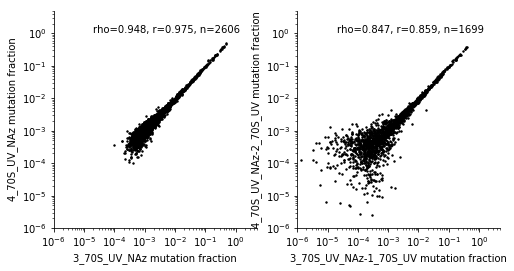

```python
import scipy.stats as stats
import numpy as np

#rewrite this to arbitrarily subtract any two libraries regardless of preferences file
def plot_correlation(axis, experiment, lib_nameX, lib_nameY, bground_nameX=None, bground_nameY=None, nucs_to_include='ATCG', color=mod_utils.black, exclude_constitutive=True):
    x = []
    y = []
    libX = experiment.get_lib_from_name(lib_nameX)
    libY = experiment.get_lib_from_name(lib_nameY)
    if bground_nameX is not None and bground_nameY is not None:
        bground_libX = experiment.get_lib_from_name(bground_nameX)
        bground_libY = experiment.get_lib_from_name(bground_nameY)
    for rRNA_name in libX.rRNA_mutation_data:
        for position in libX.rRNA_mutation_data[rRNA_name].nucleotides:
            nucX = libX.get_nucleotide(rRNA_name, position)
            nucY = libY.get_nucleotide(rRNA_name, position)
            if bground_nameX is not None and bground_nameY is not None:
                back_nucX = bground_libX.get_nucleotide(rRNA_name, position)
                back_nucY = bground_libY.get_nucleotide(rRNA_name, position)
            if libX.get_nucleotide(rRNA_name, position).identity in 'AG' and not (exclude_constitutive and nucX.exclude_constitutive):
                if bground_nameX is not None and bground_nameY is not None:
                    valX = nucX.mutation_rate-back_nucX.mutation_rate
                    valY = nucY.mutation_rate-back_nucY.mutation_rate
                else:
                    valX = nucX.mutation_rate
                    valY = nucY.mutation_rate
                if valX>0 and valY>0:
                    x.append(valX)
                    y.append(valY)
    plot.scatter(x, y, color=color, s=2)
    rho, p = stats.spearmanr(np.log10(np.array(x)), np.log10(np.array(y)))
    r, p = stats.pearsonr(np.log10(np.array(x)), np.log10(np.array(y)))
    if bground_nameX is not None and bground_nameY is not None:
        plot.set_xlabel("%s-%s mutation fraction" % (lib_nameX, bground_nameX))
        plot.set_ylabel("%s-%s mutation fraction" % (lib_nameY, bground_nameY))
    else:
        plot.set_xlabel("%s mutation fraction" % (lib_nameX))
        plot.set_ylabel("%s mutation fraction" % (lib_nameY))
    plot.set_yscale('log')
    plot.set_xscale('log')
    plot.spines['right'].set_visible(False)
    plot.spines['top'].set_visible(False)
    plot.annotate('rho=%.3f, r=%.3f, n=%d' % (rho, r, len(x)), xy=(.00002, 1), xytext=(.00002, 1))
    plot.set_xlim(.000001,5)
    plot.set_ylim(.000001,5)

fig = plt.figure(figsize=(8,4))
colors = [mod_utils.black, mod_utils.reddishPurple, mod_utils.vermillion, mod_utils.bluishGreen]

plot = fig.add_subplot(121)
plot_correlation(plot, ecoli_batch2_datasets, '3_70S_UV_NAz', '4_70S_UV_NAz', nucs_to_include='AG')
plot = fig.add_subplot(122)
plot_correlation(plot, ecoli_batch2_datasets, '3_70S_UV_NAz', '4_70S_UV_NAz', bground_nameX='1_70S_UV', bground_nameY='2_70S_UV', nucs_to_include='AG')
#plt.tight_layout()


plt.savefig('FigureS6A_mutation_reps_AG_only_%s_%s.pdf' % (current_date(), current_time()), transparent='True', format='pdf')
```

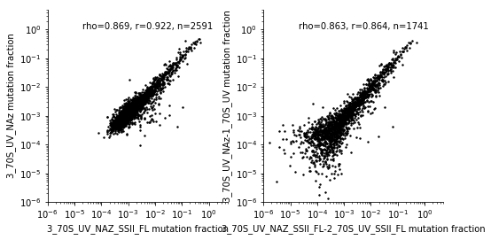

```python
import scipy.stats as stats
import numpy as np

#rewrite this to arbitrarily subtract any two libraries regardless of preferences file
def plot_correlation_between_exps(axis, experimentX, experimentY, lib_nameX, lib_nameY, bground_nameX=None, bground_nameY=None, nucs_to_include='ATCG', color=mod_utils.black, exclude_constitutive=True):
    x = []
    y = []
    libX = experimentX.get_lib_from_name(lib_nameX)
    libY = experimentY.get_lib_from_name(lib_nameY)
    if bground_nameX is not None and bground_nameY is not None:
        bground_libX = experimentX.get_lib_from_name(bground_nameX)
        bground_libY = experimentY.get_lib_from_name(bground_nameY)
    for rRNA_name in libX.rRNA_mutation_data:
        for position in libX.rRNA_mutation_data[rRNA_name].nucleotides:
            nucX = libX.get_nucleotide(rRNA_name, position)
            nucY = libY.get_nucleotide(rRNA_name, position)
            if bground_nameX is not None and bground_nameY is not None:
                back_nucX = bground_libX.get_nucleotide(rRNA_name, position)
                back_nucY = bground_libY.get_nucleotide(rRNA_name, position)
            if libX.get_nucleotide(rRNA_name, position).identity in 'AG' and not (exclude_constitutive and nucX.exclude_constitutive):
                if bground_nameX is not None and bground_nameY is not None:
                    valX = nucX.mutation_rate-back_nucX.mutation_rate
                    valY = nucY.mutation_rate-back_nucY.mutation_rate
                else:
                    valX = nucX.mutation_rate
                    valY = nucY.mutation_rate
                if valX>0 and valY>0:
                    x.append(valX)
                    y.append(valY)
    plot.scatter(x, y, color=color, s=2)
    rho, p = stats.spearmanr(np.log10(np.array(x)), np.log10(np.array(y)))
    r, p = stats.pearsonr(np.log10(np.array(x)), np.log10(np.array(y)))
    if bground_nameX is not None and bground_nameY is not None:
        plot.set_xlabel("%s-%s mutation fraction" % (lib_nameX, bground_nameX))
        plot.set_ylabel("%s-%s mutation fraction" % (lib_nameY, bground_nameY))
    else:
        plot.set_xlabel("%s mutation fraction" % (lib_nameX))
        plot.set_ylabel("%s mutation fraction" % (lib_nameY))
    plot.set_yscale('log')
    plot.set_xscale('log')
    plot.spines['right'].set_visible(False)
    plot.spines['top'].set_visible(False)
    plot.annotate('rho=%.3f, r=%.3f, n=%d' % (rho, r, len(x)), xy=(.00002, 1), xytext=(.00002, 1))
    plot.set_xlim(.000001,5)
    plot.set_ylim(.000001,5)

fig = plt.figure(figsize=(8,4))
colors = [mod_utils.black, mod_utils.reddishPurple, mod_utils.vermillion, mod_utils.bluishGreen]

plot = fig.add_subplot(121)
plot_correlation_between_exps(plot, ecoli_batch1_datasets, ecoli_batch2_datasets, '3_70S_UV_NAZ_SSII_FL', '3_70S_UV_NAz', nucs_to_include='AG')
plot = fig.add_subplot(122)
plot_correlation_between_exps(plot, ecoli_batch1_datasets, ecoli_batch2_datasets, '3_70S_UV_NAZ_SSII_FL', '3_70S_UV_NAz', bground_nameX='2_70S_UV_SSII_FL', bground_nameY='1_70S_UV', nucs_to_include='AG')
#plt.tight_layout()


plt.savefig('Figure_S6A_mutation_reps_between_exp_AG_only_%s_%s.pdf' % (current_date(), current_time()), transparent='True', format='pdf')
```

## significance calls using Weeks lab method

```python
#plot mutation CDF plots for E coli data
import scipy.stats as stats
import math
import numpy

lib_names = [ '9_70S_0_05uM_onc112_UV_NAz', '10_70S_0_25uM_onc112_UV_NAz', '11_70S_1uM_onc112_UV_NAz', '12_70S_5uM_onc112_UV_NAz']

def make_sig_change_calls(lib_name):
    library = ecoli_batch2_datasets.get_lib_from_name(lib_name)
    #compute normalization factors
    exp_mutations = []
    ctrl_mutations = []
    for rRNA_name in library.rRNA_mutation_data.keys():
        for rRNA_position in sorted(library.rRNA_mutation_data[rRNA_name].nucleotides.keys()):
            nuc = library.get_nucleotide(rRNA_name, rRNA_position)
            if nuc.identity in 'AG':
                exp_mutations.append(nuc.mutation_rate)
                ctrl_mutations.append(nuc.get_control_nucleotide().mutation_rate)
    exp_norm = numpy.mean(exp_mutations)
    ctrl_norm = numpy.mean(ctrl_mutations)

    protections = {}
    deprotections = {}
    for rRNA_name in library.rRNA_mutation_data.keys():
        positions = []
        reactivity_deltas = []
        z_factors = []
        for rRNA_position in sorted(library.rRNA_mutation_data[rRNA_name].nucleotides.keys()):
            nuc = library.get_nucleotide(rRNA_name, rRNA_position)
            if nuc.identity in 'AG' and not nuc.exclude_constitutive:
                positions.append(rRNA_position)
                control_sub=(nuc.mutation_rate/exp_norm) - (nuc.get_control_nucleotide().mutation_rate/ctrl_norm)
                reactivity_deltas.append(control_sub)
                exp_error = nuc.get_error()/exp_norm
                ctrl_error = nuc.get_control_nucleotide().get_error()/ctrl_norm
                z = 1-(1.99*(exp_error+ctrl_error)/abs(control_sub))
                z_factors.append(z)
        reactivity_delta_mean = numpy.mean(reactivity_deltas)
        reactivity_delta_std = numpy.std(reactivity_deltas)
        scores = (numpy.array(reactivity_deltas)-reactivity_delta_mean)/reactivity_delta_std
        protections[rRNA_name] = [positions[i] for i in range(len(positions)) if abs(scores[i])>0 and z_factors[i]>0 and reactivity_deltas[i]<0]
        deprotections[rRNA_name] = [positions[i] for i in range(len(positions)) if abs(scores[i])>0 and z_factors[i]>0 and reactivity_deltas[i]>0]
    return protections, deprotections

all_prot_calls = {}
all_deprot_calls = {}
for lib_name in lib_names:
   all_prot_calls[lib_name], all_deprot_calls[lib_name] = make_sig_change_calls(lib_name)
```

```python
common_prot_calls = {}
common_deprot_calls = {}
out_file = open('batch2_onc112_prot_calls_%s_%s.tsv' % (current_date(), current_time()), 'w')
out_file.write('nucleotide\tsamples with significant change\tchange type\tnumber of samples\n')
rRNAs = ['E.c.23S_rRNA', 'E.c.5S___rRNA', 'E.c.16S_rRNA']
lib_names = [ '9_70S_0_05uM_onc112_UV_NAz', '10_70S_0_25uM_onc112_UV_NAz', '11_70S_1uM_onc112_UV_NAz', '12_70S_5uM_onc112_UV_NAz']
num_libs_to_call = 4
for rRNA in rRNAs:
    common_prot_calls[rRNA]=[]
    common_deprot_calls[rRNA]=[]
    for i in range(3500):
        protected_libs = []
        for lib_name in lib_names:
            if i in all_prot_calls[lib_name][rRNA]:
                protected_libs.append(lib_name)
        if len(protected_libs)>0:
            library = ecoli_batch2_datasets.get_lib_from_name(lib_name)
            nuc = library.get_nucleotide(rRNA, i)
            out_file.write('%s_%d%s\t%s\tprotected\t%d\n' % (rRNA, i, nuc.identity, ','.join(protected_libs), len(protected_libs)))
        if len(protected_libs) >= num_libs_to_call:
            common_prot_calls[rRNA].append(i)

        deprotected_libs = []
        for lib_name in lib_names:
            if i in all_deprot_calls[lib_name][rRNA]:
                deprotected_libs.append(lib_name)
        if len(deprotected_libs)>0:
            library = ecoli_batch2_datasets.get_lib_from_name(lib_name)
            nuc = library.get_nucleotide(rRNA, i)
            out_file.write('%s_%d%s\t%s\tdeprotected\t%d\n' % (rRNA, i, nuc.identity, ','.join(deprotected_libs), len(deprotected_libs)))
        if len(deprotected_libs) >= num_libs_to_call:
            common_deprot_calls[rRNA].append(i)
out_file.close()
```

```
0.00731382587335 0.00805319597224
0.00721358772916 0.00805319597224
0.00776582509716 0.00805319597224
0.00874222985279 0.00805319597224
```

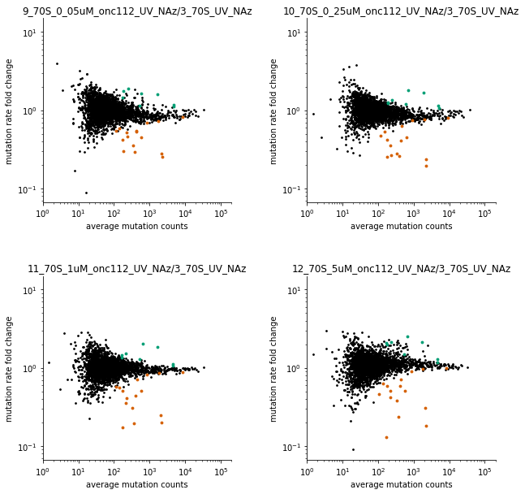

```python
import scipy.stats as stats
import math
import numpy

def plot_MA(axis, lib_name, protected_pos, deprotected_pos):
    library = ecoli_batch2_datasets.get_lib_from_name(lib_name)
    #compute normalization factors
    exp_mutations = []
    ctrl_mutations = []
    for rRNA_name in library.rRNA_mutation_data.keys():
        for rRNA_position in sorted(library.rRNA_mutation_data[rRNA_name].nucleotides.keys()):
            nuc = library.get_nucleotide(rRNA_name, rRNA_position)
            if nuc.identity in 'AG':
                exp_mutations.append(nuc.mutation_rate)
                ctrl_mutations.append(nuc.get_control_nucleotide().mutation_rate)
    exp_norm = numpy.mean(exp_mutations)
    ctrl_norm = numpy.mean(ctrl_mutations)
    print exp_norm, ctrl_norm
    x = []
    y = []
    proX = []
    proY = []
    deproX = []
    deproY = []
    for rRNA_name in library.rRNA_mutation_data.keys():
        for rRNA_position in sorted(library.rRNA_mutation_data[rRNA_name].nucleotides):
            nuc = library.get_nucleotide(rRNA_name, rRNA_position)
            if nuc.identity in 'AG':
                control_fold_change = nuc.get_control_fold_change_in_mutation_rate()
                #control_fold_change = nuc.get_control_fold_change_in_mutation_rate()*ctrl_norm/exp_norm
                avg_mutation_counts = (nuc.total_mutation_counts+nuc.get_control_nucleotide().total_mutation_counts)/2.0
                if rRNA_position in protected_pos[rRNA_name]:
                    proX.append(avg_mutation_counts)
                    proY.append(control_fold_change)
                elif rRNA_position in deprotected_pos[rRNA_name]:
                    deproX.append(avg_mutation_counts)
                    deproY.append(control_fold_change)
                else:
                    x.append(avg_mutation_counts)
                    y.append(control_fold_change)
    plot.scatter(x, y, color=mod_utils.black, s=3)
    plot.scatter(proX, proY, color = mod_utils.vermillion, s=8)
    plot.scatter(deproX, deproY, color = mod_utils.bluishGreen, s=8)
    plot.set_title('%s/%s' % (library.lib_settings.sample_name, library.get_normalizing_lib_with_mod().lib_settings.sample_name))
    ticks = plot.get_xticks()
    plot.set_xticks(ticks-.5)
    plot.set_xticklabels([int(tick) for tick in ticks])

    plot.spines['right'].set_visible(False)
    plot.spines['top'].set_visible(False)
    plot.set_ylabel('mutation rate fold change')
    plot.set_xlabel('average mutation counts')
    plot.set_yscale('log')
    plot.set_xscale('log')
    #plot.axhline(y=1, linestyle='dashed')

    plot.set_xlim(1,200000)
    plot.set_ylim(1/15.,15)


fig = plt.figure(figsize=(10,10))
fig.subplots_adjust(wspace=0.4, hspace=0.4)
plot = fig.add_subplot(221)
plot_MA(plot, '9_70S_0_05uM_onc112_UV_NAz', common_prot_calls, common_deprot_calls)
plot = fig.add_subplot(222)
plot_MA(plot, '10_70S_0_25uM_onc112_UV_NAz', common_prot_calls, common_deprot_calls)
plot = fig.add_subplot(223)
plot_MA(plot, '11_70S_1uM_onc112_UV_NAz', common_prot_calls, common_deprot_calls)
plot = fig.add_subplot(224)
plot_MA(plot, '12_70S_5uM_onc112_UV_NAz', common_prot_calls, common_deprot_calls)
plt.savefig('Figure 5A_S8B_onc112_MA_plots_smola_calls_%s_%s.pdf' % (current_date(), current_time()), transparent='True', format='pdf')
```

```python
from bokeh.plotting import figure, output_file, save, ColumnDataSource, gridplot
from bokeh.io import push_notebook, output_notebook, show, export_svgs
from bokeh.models import Range1d
from bokeh.models import HoverTool
from collections import OrderedDict
output_notebook()

# output to static HTML file
#output_file("%s.html" % (out_prefix))
plot_figs=[]
nucleotides_to_count='AG'
for sample_name in ['9_70S_0_05uM_onc112_UV_NAz', '10_70S_0_25uM_onc112_UV_NAz', '11_70S_1uM_onc112_UV_NAz', '12_70S_5uM_onc112_UV_NAz']:
    library = ecoli_batch2_datasets.get_lib_from_name(sample_name)
    x, y, anno = [], [], []
    pro_x, pro_y, pro_anno = [], [], []
    depro_x, depro_y, depro_anno = [], [], []
    for rRNA_name in library.rRNA_mutation_data:
        for position in library.rRNA_mutation_data[rRNA_name].nucleotides:
            nucleotide = library.rRNA_mutation_data[rRNA_name].nucleotides[position]
            if  nucleotide.exclude_constitutive or nucleotide.identity not in nucleotides_to_count:
                continue
            else:
                control_fold_change = nucleotide.get_control_fold_change_in_mutation_rate()
                avg_mutation_counts = (nucleotide.total_mutation_counts+nucleotide.get_control_nucleotide().total_mutation_counts)/2.0
                if control_fold_change == 0:
                    control_fold_change = 1/15.
                elif control_fold_change == float('inf'):
                    control_fold_change = 15.
                if position in common_prot_calls[rRNA_name]:
                    pro_x.append(avg_mutation_counts)
                    pro_y.append(control_fold_change)
                    pro_anno.append('%s_%s%d' %(rRNA_name,nucleotide.identity,position))
                elif position in common_deprot_calls[rRNA_name]:
                    depro_x.append(avg_mutation_counts)
                    depro_y.append(control_fold_change)
                    depro_anno.append('%s_%s%d' %(rRNA_name,nucleotide.identity,position))
                else:
                    x.append(avg_mutation_counts)
                    y.append(control_fold_change)
                    anno.append('%s_%s%d' %(rRNA_name,nucleotide.identity,position))
    source = ColumnDataSource(data=dict(x = x, y = y, label = anno))
    prot_source = ColumnDataSource(data=dict(x = pro_x, y = pro_y, label = pro_anno))
    deprot_source = ColumnDataSource(data=dict(x = depro_x, y = depro_y, label = depro_anno))
    TOOLS = "pan,wheel_zoom,reset,save,hover"
    PlotFig = figure(x_axis_label = "average mutation counts",
                     y_axis_label = "mutation rate fold change",
                     y_axis_type="log", x_axis_type="log", title=sample_name, tools=TOOLS, toolbar_location="right")
    PlotFig.circle("x", "y", size = 5, source=source, color=mod_utils.bokeh_black)
    PlotFig.circle("x", "y", size = 5, source=prot_source, color=mod_utils.bokeh_vermillion)
    PlotFig.circle("x", "y", size = 5, source=deprot_source, color=mod_utils.bokeh_bluishGreen)
    #PlotFig.x_range = Range1d(start=0.00001, end=1)
    PlotFig.y_range = Range1d(start=1/15., end=15.)

    #adjust what information you get when you hover over it
    Hover = PlotFig.select(dict(type=HoverTool))
    Hover.tooltips = OrderedDict([("nuc", "@label")])
    plot_figs.append(PlotFig)
#p = gridplot(plot_figs)

show(gridplot(children=plot_figs, ncols=2, plot_width=400, plot_height=400), notebook_handle=True)
```

[interactive chart not shown]

`<Bokeh Notebook handle for In[34]>`